# *Stellar Classification Notebook*

#### Advanced Machine Learning course

#### MSc in Data Science for Management

**Table of contents:**

1. Introduction
1. Getting in touch with the dataset
1. Exploratory data analysis
1. Supervised Learning Techninques

   4.1 Model Selection

   4.2 Achieved Results and further application
1. Unsupervised Learning Techniques

   5.1 Principal Component Analysis

   5.2 K-means
1. Semi-supervised Learning Techniques

   6.1 Label Propagation

   6.2 Co-training
1. Comparison with other studies

## 1. Introduction

In astronomy, stellar classification is the classification of stars based on their spectral characteristics. The classification scheme of galaxies, quasars, and stars is one of the most fundamental in astronomy. The early cataloguing of stars and their distribution in the sky has led to the understanding that they make up our own galaxy and, following the distinction that Andromeda was a separate galaxy to our own, numerous galaxies began to be surveyed as more powerful telescopes were built. This datasat aims to classificate stars, galaxies, and quasars based on their spectral characteristics.

The dataset consists of 100,000 observations of space taken by the SDSS (Sloan Digital Sky Survey). Every observation is described by 17 feature columns and 1 class column which identifies it to be either a star, galaxy or quasar.

*Features*

1. obj_ID = Object Identifier, the unique value that identifies the object in the image catalog used by the CAS
2. alpha = Right Ascension angle (at J2000 epoch)
3. delta = Declination angle (at J2000 epoch)
4. u = Ultraviolet filter in the photometric system
5. g = Green filter in the photometric system
6. r = Red filter in the photometric system
7. i = Near Infrared filter in the photometric system
8. z = Infrared filter in the photometric system
9. run_ID = Run Number used to identify the specific scan
10. rereun_ID = Rerun Number to specify how the image was processed
11. cam_col = Camera column to identify the scanline within the run
12. field_ID = Field number to identify each field
13. spec_obj_ID = Unique ID used for optical spectroscopic objects (this means that 2 different observations with the same spec_obj_ID must share the output class)
14. class = object class (galaxy, star or quasar object)
15. redshift = redshift value based on the increase in wavelength
16. plate = plate ID, identifies each plate in SDSS
17. MJD = Modified Julian Date, used to indicate when a given piece of SDSS data was taken
18. fiber_ID = fiber ID that identifies the fiber that pointed the light at the focal plane in each observation

## 2. Getting in touch with the dataset

To get in touch with the dataset, it is needed to know some information about it in such a way that we can manage upcoming problems. In order to develop the analysis, some basic libraries must be included in the code.

```python
import numpy as np
import pandas as pd
import warnings
warnings.filterwarnings("ignore")
```

Now there is the upload of the dataset in the *csv* type; after his representation. Note that I decided to remove some features because they are irrilevant for the analysis; they aren't spectral characteristics, they are part of the experiments they carried on to take all those pictures. So, I removed them because they add "noise" to the modelling phase.

```python
data = pd.read_csv(r"\Users\Turex\Desktop\AML\star_classification.csv")
data = data.drop(['obj_ID','alpha','delta','run_ID','rerun_ID','cam_col','field_ID','fiber_ID','plate','MJD','spec_obj_ID'], axis = 1)
data.head()
```

|  | u | g | r | i | z | class | redshift |
| --- | --- | --- | --- | --- | --- | --- | --- |
| 0 | 23.87882 | 22.27530 | 20.39501 | 19.16573 | 18.79371 | GALAXY | 0.634794 |
| 1 | 24.77759 | 22.83188 | 22.58444 | 21.16812 | 21.61427 | GALAXY | 0.779136 |
| 2 | 25.26307 | 22.66389 | 20.60976 | 19.34857 | 18.94827 | GALAXY | 0.644195 |
| 3 | 22.13682 | 23.77656 | 21.61162 | 20.50454 | 19.25010 | GALAXY | 0.932346 |
| 4 | 19.43718 | 17.58028 | 16.49747 | 15.97711 | 15.54461 | GALAXY | 0.116123 |

To discover the shape of the dataset, in term of rows and columns, is possible to:

```python
data.shape
```

```
(100000, 7)
```

Some dataset's information:

```python
data.info()
```

```
<class 'pandas.core.frame.DataFrame'>
RangeIndex: 100000 entries, 0 to 99999
Data columns (total 7 columns):
 #   Column    Non-Null Count   Dtype
---  ------    --------------   -----
 0   u         100000 non-null  float64
 1   g         100000 non-null  float64
 2   r         100000 non-null  float64
 3   i         100000 non-null  float64
 4   z         100000 non-null  float64
 5   class     100000 non-null  object
 6   redshift  100000 non-null  float64
dtypes: float64(6), object(1)
memory usage: 5.3+ MB
```

Checking for null values:

```python
data.isnull().sum()
```

```
u           0
g           0
r           0
i           0
z           0
class       0
redshift    0
dtype: int64
```

As it can be observed, there aren't *NULL VALUES*

## 3. Exploratory data analysis

Libraries used in this topic:

```python
import seaborn as sns
import matplotlib.pyplot as plt
from sklearn.preprocessing import LabelEncoder
from imblearn.over_sampling import SMOTE
from collections import Counter
```

Starting with this topic, the goal is to look for patterns and summarize the dataset’s main characteristics. It's better to use a descriptive approach for some statistical measures; with the following box I am going to show the main statistical measures of each feature.

```python
data.describe().T
```

|  | count | mean | std | min | 25% | 50% | 75% | max |
| --- | --- | --- | --- | --- | --- | --- | --- | --- |
| u | 100000.0 | 21.980468 | 31.769291 | -9999.000000 | 20.352353 | 22.179135 | 23.687440 | 32.781390 |
| g | 100000.0 | 20.531387 | 31.750292 | -9999.000000 | 18.965230 | 21.099835 | 22.123767 | 31.602240 |
| r | 100000.0 | 19.645762 | 1.854760 | 9.822070 | 18.135828 | 20.125290 | 21.044785 | 29.571860 |
| i | 100000.0 | 19.084854 | 1.757895 | 9.469903 | 17.732285 | 19.405145 | 20.396495 | 32.141470 |
| z | 100000.0 | 18.668810 | 31.728152 | -9999.000000 | 17.460677 | 19.004595 | 19.921120 | 29.383740 |
| redshift | 100000.0 | 0.576661 | 0.730707 | -0.009971 | 0.054517 | 0.424173 | 0.704154 | 7.011245 |

An observation in the dataset has a value of -9999 for variables "u", "g" and "z"; it's an outlier!

```python
outlier = data[data['u'] == -9999.000].index
data.drop(outlier,inplace = True)
```

Now, with this operation, the abnormal value has been removed; it can be verified in the following box:

```python
data.describe().T
```

|  | count | mean | std | min | 25% | 50% | 75% | max |
| --- | --- | --- | --- | --- | --- | --- | --- | --- |
| u | 99999.0 | 22.080679 | 2.251068 | 10.996230 | 20.352410 | 22.179140 | 23.687480 | 32.781390 |
| g | 99999.0 | 20.631583 | 2.037384 | 10.498200 | 18.965240 | 21.099930 | 22.123775 | 31.602240 |
| r | 99999.0 | 19.645777 | 1.854763 | 9.822070 | 18.135795 | 20.125310 | 21.044790 | 29.571860 |
| i | 99999.0 | 19.084865 | 1.757900 | 9.469903 | 17.732280 | 19.405150 | 20.396510 | 32.141470 |
| z | 99999.0 | 18.768988 | 1.765982 | 9.612333 | 17.460830 | 19.004600 | 19.921120 | 29.383740 |
| redshift | 99999.0 | 0.576667 | 0.730709 | -0.009971 | 0.054522 | 0.424176 | 0.704172 | 7.011245 |

It is interesting to discover the frequency of the classes in the dataset, that are star, galaxy and quasar, also to know if the dataset is balanced or not:

```python
data["class"] = [0 if i == "GALAXY" else 1 if i == "STAR" else 2 for i in data["class"]]
data["class"].value_counts()
```

```
0    59445
1    21593
2    18961
Name: class, dtype: int64
```

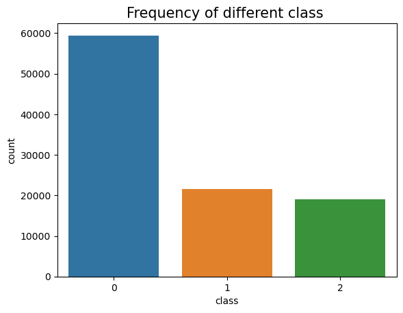

```python
sns.countplot(x = data["class"])
plt.title("Frequency of different class ", fontsize = 15)
plt.show()
```

Based on the previous code and plot, seems that the dataset is imbalanced; this problem can be solved with the *SMOTE* (Synthetic Minority Oversampling Technique) approach;

```python
x = data.drop(['class'], axis = 1)
y = data.loc[:,'class'].values
s = SMOTE(random_state = 42)
print('Original dataset shape %s' % Counter(y))
x, y = s.fit_resample(x, y)
print('Resampled dataset shape %s' % Counter(y))
```

```
Original dataset shape Counter({0: 59445, 1: 21593, 2: 18961})
Resampled dataset shape Counter({0: 59445, 2: 59445, 1: 59445})
```

After the *SMOTE*'s application, it can be noticed that the dataset now is perfectly balanced.

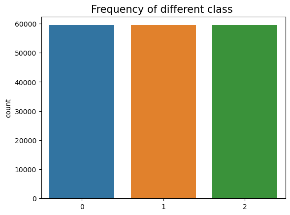

```python
sns.countplot(x = y)
plt.title("Frequency of different class ", fontsize = 15)
plt.show()
```

Now let's check the correlation among the features by looking to Pearson, Spearman and Kendall.

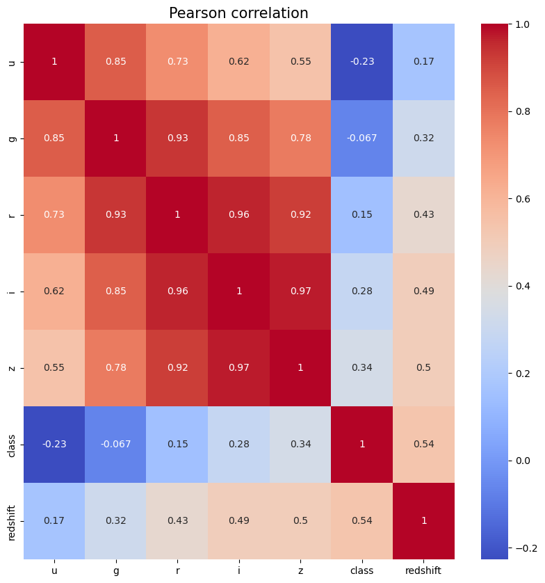

```python
plt.figure(figsize = (10,10))
sns.heatmap(data.corr(), cmap = 'coolwarm', annot = True);
plt.title("Pearson correlation",fontsize = 15)
```

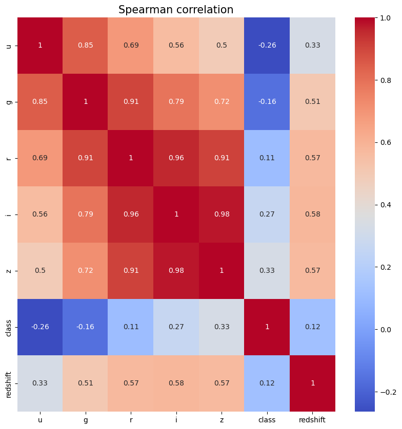

```python
plt.figure(figsize = (10,10))
sns.heatmap(data.corr(method = "spearman"), cmap = 'coolwarm', annot = True);
plt.title("Spearman correlation", fontsize = 15)
```

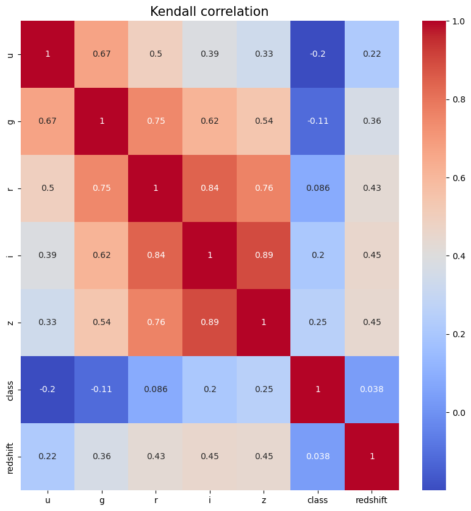

```python
plt.figure(figsize = (10,10))
sns.heatmap(data.corr(method = "kendall"), cmap = 'coolwarm', annot = True);
plt.title("Kendall correlation", fontsize = 15)
```

## 4. Supervised Learning Techniques

*Supervised learning* is a type of machine learning in which a model is trained on labeled examples to make predictions about new, unseen data. In supervised learning, the goal is to learn a function that maps input data to output labels, based on a labeled training set of examples.

Libraries and functions used in this chapter:

```python
from sklearn.preprocessing import StandardScaler
from sklearn.linear_model import LogisticRegression
from sklearn.neighbors import KNeighborsClassifier
from sklearn.ensemble import BaggingClassifier, AdaBoostClassifier, RandomForestClassifier, ExtraTreesClassifier
from sklearn.tree import DecisionTreeClassifier
from xgboost import XGBClassifier
from sklearn.naive_bayes import GaussianNB
from sklearn.model_selection import train_test_split, cross_val_score, GridSearchCV
from sklearn.metrics import confusion_matrix, accuracy_score, classification_report

def evaluate_model_cv(model, x_train, y_train, cv=10):
  scores = cross_val_score(model, x_train, y_train, cv=cv)
  print("Cross-validation scores:", scores)
  print("Mean score:", np.mean(scores))
  print("Standard deviation:", np.std(scores))

def grid_search(grid, estimator, x_train, y_train,cv=10):
    grid_search = GridSearchCV(estimator=estimator, param_grid=grid, scoring='accuracy', verbose=5,cv=cv)
    grid_result = grid_search.fit(x_train, y_train)
    print("Best: %f using %s" % (grid_result.best_score_, grid_result.best_params_))
    return grid_result.best_estimator_

def test_and_conf(name, model, x_train, x_test, y_train, y_test):
  model.fit(x_train, y_train)
  y_pred = model.predict(x_test)
  print(f"Accuracy Score for {name} is : ",(model.score(x_test, y_test)) *100, "%")
  report = classification_report(y_test, y_pred)
  print(f'{name} model classification report:')
  print(report)
  cm = confusion_matrix(y_test, y_pred)
  cm_df = pd.DataFrame(cm, index=['GALAXY', 'STAR', 'QSO'], columns=['GALAXY', 'STAR','QSO'])
  print(f'{name} model confusion matrix:')
  sns.heatmap(cm_df, annot=True, fmt='d')
```

Before to start the data modelling phase, the data must be scaled in order to allow the machine learning model to better understand and learn the problem.

```python
scaler = StandardScaler()
scaler.fit(x)
x = scaler.transform(x)
```

After the data scaling, there is one of the most important part, that consists in splitting the data in train set and test set. In this way, I will use the train set to train the model with the function *evaluate_model*, that has implemented the *cross-validation*.

```python
x_train, x_test, y_train, y_test = train_test_split(x, y, test_size = 0.33, random_state = 42)
```

Now the dataset has been splitted into 67% for training set and 33% for test set.

### 4.1 Model selection

All the process needed for the application of the supervised learning techniques have been applied.

To predict stars, galaxies and quasars, I employed nine different supervised learning methods from different machine learning areas. The classifiers include the Logistic Regression, an instance - based learning model (k-Nearest Neighbors), two ensemble meta-estimator (Bagging Classifier and AdaBoost Classifier), an algorithms under the Gradient Boosting framework (XGB Classifier), tree - based methods (Random Forests, Decision Trees and Extra Trees), and a probabilistic classifiers called GaussianNB. The framework that I used to try the models is always the same for each model.

At first I used the *evaluate_model_cv*, a function that uses the cross_val_score function from the sklearn.model_selection module to evaluate the model on the training set using cross-validation. It then prints the cross-validation scores, the mean score, and the standard deviation of the scores.

At second I used the *grid_search* function that work strictly with a *paramters grid*. It uses the GridSearchCV function from the sklearn.model_selection module to perform grid search; the function prints the best score and the best hyperparameters found by the grid search, and returns the best estimator found by the search.

At the end I used the *test_and_conf* function that tests a machine learning model on a test set and displays a confusion matrix of the model's performance. Confusion matrices are a useful tool for evaluating the performance of a classification model, as they provide a detailed breakdown of the number of correct and incorrect predictions made by the model.

#### Logistic Regression

```python
evaluate_model_cv(LogisticRegression(), x_train, y_train)
```

```
Cross-validation scores: [0.94828019 0.95070717 0.94928446 0.94710854 0.94768999 0.94819217
 0.95028457 0.94810847 0.95003348 0.94944761]
Mean score: 0.9489136643759076
Standard deviation: 0.0011444925302629449
```

```python
param_grid_logreg = {'C': [0.1, 1, 10], 'penalty': ['l1', 'l2']}
grid_search(param_grid_logreg, LogisticRegression(), x_train, y_train)
```

```
Fitting 10 folds for each of 6 candidates, totalling 60 fits
[CV 1/10] END ..................C=0.1, penalty=l1;, score=nan total time=   0.0s
[CV 2/10] END ..................C=0.1, penalty=l1;, score=nan total time=   0.0s
[CV 3/10] END ..................C=0.1, penalty=l1;, score=nan total time=   0.0s
[CV 4/10] END ..................C=0.1, penalty=l1;, score=nan total time=   0.0s
[CV 5/10] END ..................C=0.1, penalty=l1;, score=nan total time=   0.0s
[CV 6/10] END ..................C=0.1, penalty=l1;, score=nan total time=   0.0s
[CV 7/10] END ..................C=0.1, penalty=l1;, score=nan total time=   0.0s
[CV 8/10] END ..................C=0.1, penalty=l1;, score=nan total time=   0.0s
[CV 9/10] END ..................C=0.1, penalty=l1;, score=nan total time=   0.0s
[CV 10/10] END .................C=0.1, penalty=l1;, score=nan total time=   0.0s
[CV 1/10] END ................C=0.1, penalty=l2;, score=0.940 total time=   2.4s
[CV 2/10] END ................C=0.1, penalty=l2;, score=0.941 total time=   2.0s
[CV 3/10] END ................C=0.1, penalty=l2;, score=0.940 total time=   2.0s
[CV 4/10] END ................C=0.1, penalty=l2;, score=0.935 total time=   2.1s
[CV 5/10] END ................C=0.1, penalty=l2;, score=0.938 total time=   2.0s
[CV 6/10] END ................C=0.1, penalty=l2;, score=0.938 total time=   2.0s
[CV 7/10] END ................C=0.1, penalty=l2;, score=0.941 total time=   2.0s
[CV 8/10] END ................C=0.1, penalty=l2;, score=0.937 total time=   2.2s
[CV 9/10] END ................C=0.1, penalty=l2;, score=0.940 total time=   2.1s
[CV 10/10] END ...............C=0.1, penalty=l2;, score=0.939 total time=   2.0s
[CV 1/10] END ....................C=1, penalty=l1;, score=nan total time=   0.0s
[CV 2/10] END ....................C=1, penalty=l1;, score=nan total time=   0.0s
[CV 3/10] END ....................C=1, penalty=l1;, score=nan total time=   0.0s
[CV 4/10] END ....................C=1, penalty=l1;, score=nan total time=   0.0s
[CV 5/10] END ....................C=1, penalty=l1;, score=nan total time=   0.0s
[CV 6/10] END ....................C=1, penalty=l1;, score=nan total time=   0.0s
[CV 7/10] END ....................C=1, penalty=l1;, score=nan total time=   0.0s
[CV 8/10] END ....................C=1, penalty=l1;, score=nan total time=   0.0s
[CV 9/10] END ....................C=1, penalty=l1;, score=nan total time=   0.0s
[CV 10/10] END ...................C=1, penalty=l1;, score=nan total time=   0.0s
[CV 1/10] END ..................C=1, penalty=l2;, score=0.948 total time=   2.1s
[CV 2/10] END ..................C=1, penalty=l2;, score=0.951 total time=   2.3s
[CV 3/10] END ..................C=1, penalty=l2;, score=0.949 total time=   2.3s
[CV 4/10] END ..................C=1, penalty=l2;, score=0.947 total time=   2.2s
[CV 5/10] END ..................C=1, penalty=l2;, score=0.948 total time=   1.9s
[CV 6/10] END ..................C=1, penalty=l2;, score=0.948 total time=   2.2s
[CV 7/10] END ..................C=1, penalty=l2;, score=0.950 total time=   2.2s
[CV 8/10] END ..................C=1, penalty=l2;, score=0.948 total time=   2.2s
[CV 9/10] END ..................C=1, penalty=l2;, score=0.950 total time=   2.1s
[CV 10/10] END .................C=1, penalty=l2;, score=0.949 total time=   2.1s
[CV 1/10] END ...................C=10, penalty=l1;, score=nan total time=   0.0s
[CV 2/10] END ...................C=10, penalty=l1;, score=nan total time=   0.0s
[CV 3/10] END ...................C=10, penalty=l1;, score=nan total time=   0.0s
[CV 4/10] END ...................C=10, penalty=l1;, score=nan total time=   0.0s
[CV 5/10] END ...................C=10, penalty=l1;, score=nan total time=   0.0s
[CV 6/10] END ...................C=10, penalty=l1;, score=nan total time=   0.0s
[CV 7/10] END ...................C=10, penalty=l1;, score=nan total time=   0.0s
[CV 8/10] END ...................C=10, penalty=l1;, score=nan total time=   0.0s
[CV 9/10] END ...................C=10, penalty=l1;, score=nan total time=   0.0s
[CV 10/10] END ..................C=10, penalty=l1;, score=nan total time=   0.0s
[CV 1/10] END .................C=10, penalty=l2;, score=0.954 total time=   2.2s
[CV 2/10] END .................C=10, penalty=l2;, score=0.956 total time=   2.2s
[CV 3/10] END .................C=10, penalty=l2;, score=0.954 total time=   2.1s
[CV 4/10] END .................C=10, penalty=l2;, score=0.953 total time=   2.2s
[CV 5/10] END .................C=10, penalty=l2;, score=0.953 total time=   2.2s
[CV 6/10] END .................C=10, penalty=l2;, score=0.954 total time=   2.3s
[CV 7/10] END .................C=10, penalty=l2;, score=0.956 total time=   2.7s
[CV 8/10] END .................C=10, penalty=l2;, score=0.954 total time=   2.4s
[CV 9/10] END .................C=10, penalty=l2;, score=0.954 total time=   2.1s
[CV 10/10] END ................C=10, penalty=l2;, score=0.955 total time=   2.1s
Best: 0.954295 using {'C': 10, 'penalty': 'l2'}
```

```
LogisticRegression(C=10)
```

```
Accuracy Score for Logistic Regression is :  95.2592139470867 %
Logistic Regression model classification report:
              precision    recall  f1-score   support

           0       0.92      0.94      0.93     19642
           1       0.98      1.00      0.99     19507
           2       0.95      0.92      0.94     19702

    accuracy                           0.95     58851
   macro avg       0.95      0.95      0.95     58851
weighted avg       0.95      0.95      0.95     58851

Logistic Regression model confusion matrix:
```

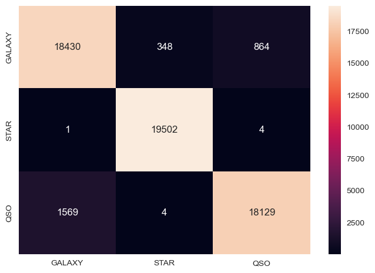

```python
test_and_conf("Logistic Regression", LogisticRegression(penalty = 'l2', C = 10), x_train, x_test, y_train, y_test)
```

- 18430 are the true positives, instances that are predicted to belong to *galaxy* and actually belong to it
- 348 are the false positives, instances that are predicted to belong to *galaxy* but actually belong to *star*
- 864 are the false negatives, instances that are predicted to belong to *galaxy* but actually belong to *qso*
- 1 is the false negative, instance that is predicted to belong to *star* but actually belong to class *galaxy*
- 19502 are the true positives, instances that are predicted to belong to *star* and actually belong to it
- 4 are the false postives, instances that are predicetd to belong to *star* but actually belong to *qso*
- 1569 are the false positives, instances that are predicted to belong to *qso* but actually belong to *galaxy*
- 4 are the false negatives, instances that are predicted to belong to *qso* but actually belong to *star*
- 18129 are the true positives, instances that are predicted to belong to *qso* and acutally belong to it

#### K-nearest Neighbors

```python
evaluate_model_cv(KNeighborsClassifier(), x_train, y_train)
```

```
Cross-validation scores: [0.96928613 0.9710436  0.96819818 0.96736129 0.97012052 0.96601942
 0.96869769 0.96819551 0.9663542  0.96945095]
Mean score: 0.9684727495045552
Standard deviation: 0.0015128846136823217
```

```python
param_grid_knn = {"n_neighbors": list(range(2,30, 3))}
grid_search(param_grid_knn, KNeighborsClassifier(), x_train, y_train)
```

```
Fitting 10 folds for each of 10 candidates, totalling 100 fits
[CV 1/10] END ....................n_neighbors=2;, score=0.970 total time=   0.4s
[CV 2/10] END ....................n_neighbors=2;, score=0.972 total time=   0.4s
[CV 3/10] END ....................n_neighbors=2;, score=0.969 total time=   0.4s
[CV 4/10] END ....................n_neighbors=2;, score=0.969 total time=   0.4s
[CV 5/10] END ....................n_neighbors=2;, score=0.973 total time=   0.4s
[CV 6/10] END ....................n_neighbors=2;, score=0.967 total time=   0.4s
[CV 7/10] END ....................n_neighbors=2;, score=0.971 total time=   0.4s
[CV 8/10] END ....................n_neighbors=2;, score=0.969 total time=   0.4s
[CV 9/10] END ....................n_neighbors=2;, score=0.968 total time=   0.4s
[CV 10/10] END ...................n_neighbors=2;, score=0.972 total time=   0.4s
[CV 1/10] END ....................n_neighbors=5;, score=0.969 total time=   0.4s
[CV 2/10] END ....................n_neighbors=5;, score=0.971 total time=   0.4s
[CV 3/10] END ....................n_neighbors=5;, score=0.968 total time=   0.4s
[CV 4/10] END ....................n_neighbors=5;, score=0.967 total time=   0.4s
[CV 5/10] END ....................n_neighbors=5;, score=0.970 total time=   0.4s
[CV 6/10] END ....................n_neighbors=5;, score=0.966 total time=   0.4s
[CV 7/10] END ....................n_neighbors=5;, score=0.969 total time=   0.4s
[CV 8/10] END ....................n_neighbors=5;, score=0.968 total time=   0.4s
[CV 9/10] END ....................n_neighbors=5;, score=0.966 total time=   0.4s
[CV 10/10] END ...................n_neighbors=5;, score=0.969 total time=   0.4s
[CV 1/10] END ....................n_neighbors=8;, score=0.966 total time=   0.4s
[CV 2/10] END ....................n_neighbors=8;, score=0.969 total time=   0.4s
[CV 3/10] END ....................n_neighbors=8;, score=0.966 total time=   0.4s
[CV 4/10] END ....................n_neighbors=8;, score=0.966 total time=   0.4s
[CV 5/10] END ....................n_neighbors=8;, score=0.968 total time=   0.4s
[CV 6/10] END ....................n_neighbors=8;, score=0.964 total time=   0.4s
[CV 7/10] END ....................n_neighbors=8;, score=0.968 total time=   0.4s
[CV 8/10] END ....................n_neighbors=8;, score=0.966 total time=   0.4s
[CV 9/10] END ....................n_neighbors=8;, score=0.965 total time=   0.4s
[CV 10/10] END ...................n_neighbors=8;, score=0.967 total time=   0.4s
[CV 1/10] END ...................n_neighbors=11;, score=0.963 total time=   0.5s
[CV 2/10] END ...................n_neighbors=11;, score=0.967 total time=   0.5s
[CV 3/10] END ...................n_neighbors=11;, score=0.963 total time=   0.5s
[CV 4/10] END ...................n_neighbors=11;, score=0.965 total time=   0.5s
[CV 5/10] END ...................n_neighbors=11;, score=0.966 total time=   0.4s
[CV 6/10] END ...................n_neighbors=11;, score=0.961 total time=   0.5s
[CV 7/10] END ...................n_neighbors=11;, score=0.966 total time=   0.5s
[CV 8/10] END ...................n_neighbors=11;, score=0.963 total time=   0.4s
[CV 9/10] END ...................n_neighbors=11;, score=0.964 total time=   0.5s
```

[output cut: 47 more lines]

```
[CV 7/10] END ...................n_neighbors=26;, score=0.960 total time=   0.5s
[CV 8/10] END ...................n_neighbors=26;, score=0.957 total time=   0.5s
[CV 9/10] END ...................n_neighbors=26;, score=0.957 total time=   0.5s
[CV 10/10] END ..................n_neighbors=26;, score=0.958 total time=   0.5s
[CV 1/10] END ...................n_neighbors=29;, score=0.958 total time=   0.6s
[CV 2/10] END ...................n_neighbors=29;, score=0.960 total time=   0.6s
[CV 3/10] END ...................n_neighbors=29;, score=0.958 total time=   0.5s
[CV 4/10] END ...................n_neighbors=29;, score=0.955 total time=   0.6s
[CV 5/10] END ...................n_neighbors=29;, score=0.960 total time=   0.6s
[CV 6/10] END ...................n_neighbors=29;, score=0.955 total time=   0.6s
[CV 7/10] END ...................n_neighbors=29;, score=0.959 total time=   0.6s
[CV 8/10] END ...................n_neighbors=29;, score=0.957 total time=   0.6s
[CV 9/10] END ...................n_neighbors=29;, score=0.957 total time=   0.6s
[CV 10/10] END ..................n_neighbors=29;, score=0.958 total time=   0.6s
Best: 0.970088 using {'n_neighbors': 2}
```

```
KNeighborsClassifier(n_neighbors=2)
```

```
Accuracy Score for KNN Classifier is :  97.06716963178195 %
KNN Classifier model classification report:
              precision    recall  f1-score   support

           0       0.95      0.96      0.96     19642
           1       0.98      0.99      0.98     19507
           2       0.98      0.97      0.97     19702

    accuracy                           0.97     58851
   macro avg       0.97      0.97      0.97     58851
weighted avg       0.97      0.97      0.97     58851

KNN Classifier model confusion matrix:
```

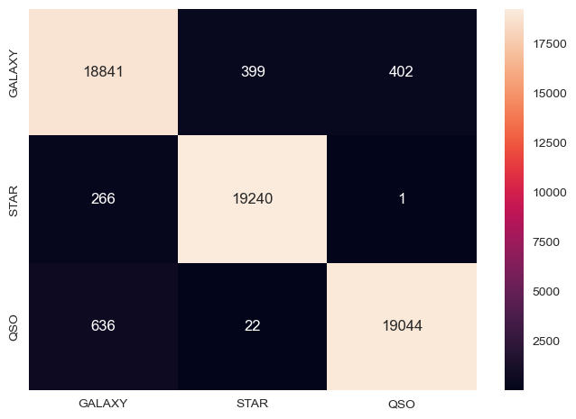

```python
test_and_conf("KNN Classifier", KNeighborsClassifier(n_neighbors = 2), x_train, x_test, y_train, y_test)
```

- 18841 are the true positives, instances that are predicted to belong to *galaxy* and actually belong to it
- 399 are the false positives, instances that are predicted to belong to *galaxy* but actually belong to *star*
- 402 are the false negatives, instances that are predicted to belong to *galaxy* but actually belong to *qso*
- 266 are the false negative, instances that are predicted to belong to *star* but actually belong to class *galaxy*
- 19240 are the true positives, instances that are predicted to belong to *star* and actually belong to it
- 1 is the false postive, instance that is predicetd to belong to *star* but actually belong to *qso*
- 636 are the false positives, instances that are predicted to belong to *qso* but actually belong to *galaxy*
- 22 are the false negatives, instances that are predicted to belong to *qso* but actually belong to *star*
- 19044 are the true positives, instances that are predicted to belong to *qso* and acutally belong to it

#### Bagging

```python
evaluate_model_cv(BaggingClassifier(), x_train, y_train)
```

```
Cross-validation scores: [0.97999833 0.97991464 0.97757134 0.97999833 0.97991296 0.9768999
 0.98058252 0.97941078 0.97932708 0.9810847 ]
Mean score: 0.979470057895593
Standard deviation: 0.0012260251449971284
```

```python
param_grid_bagg = {
    'n_estimators': [10, 20],
    'max_samples': [0.2, 0.5, 1.0],
}
grid_search(param_grid_bagg, BaggingClassifier(), x_train, y_train)
```

```
Fitting 10 folds for each of 6 candidates, totalling 60 fits
[CV 1/10] END .max_samples=0.2, n_estimators=10;, score=0.976 total time=   1.0s
[CV 2/10] END .max_samples=0.2, n_estimators=10;, score=0.977 total time=   1.0s
[CV 3/10] END .max_samples=0.2, n_estimators=10;, score=0.975 total time=   1.0s
[CV 4/10] END .max_samples=0.2, n_estimators=10;, score=0.976 total time=   1.0s
[CV 5/10] END .max_samples=0.2, n_estimators=10;, score=0.977 total time=   1.0s
[CV 6/10] END .max_samples=0.2, n_estimators=10;, score=0.975 total time=   1.0s
[CV 7/10] END .max_samples=0.2, n_estimators=10;, score=0.978 total time=   1.0s
[CV 8/10] END .max_samples=0.2, n_estimators=10;, score=0.975 total time=   1.0s
[CV 9/10] END .max_samples=0.2, n_estimators=10;, score=0.975 total time=   1.0s
[CV 10/10] END max_samples=0.2, n_estimators=10;, score=0.977 total time=   1.0s
[CV 1/10] END .max_samples=0.2, n_estimators=20;, score=0.977 total time=   2.1s
[CV 2/10] END .max_samples=0.2, n_estimators=20;, score=0.980 total time=   2.1s
[CV 3/10] END .max_samples=0.2, n_estimators=20;, score=0.975 total time=   2.0s
[CV 4/10] END .max_samples=0.2, n_estimators=20;, score=0.978 total time=   2.0s
[CV 5/10] END .max_samples=0.2, n_estimators=20;, score=0.978 total time=   2.1s
[CV 6/10] END .max_samples=0.2, n_estimators=20;, score=0.974 total time=   2.1s
[CV 7/10] END .max_samples=0.2, n_estimators=20;, score=0.978 total time=   2.1s
[CV 8/10] END .max_samples=0.2, n_estimators=20;, score=0.976 total time=   2.1s
[CV 9/10] END .max_samples=0.2, n_estimators=20;, score=0.976 total time=   2.0s
[CV 10/10] END max_samples=0.2, n_estimators=20;, score=0.978 total time=   2.0s
[CV 1/10] END .max_samples=0.5, n_estimators=10;, score=0.977 total time=   2.6s
[CV 2/10] END .max_samples=0.5, n_estimators=10;, score=0.978 total time=   2.6s
[CV 3/10] END .max_samples=0.5, n_estimators=10;, score=0.976 total time=   2.7s
[CV 4/10] END .max_samples=0.5, n_estimators=10;, score=0.977 total time=   2.6s
[CV 5/10] END .max_samples=0.5, n_estimators=10;, score=0.979 total time=   2.5s
[CV 6/10] END .max_samples=0.5, n_estimators=10;, score=0.977 total time=   2.7s
[CV 7/10] END .max_samples=0.5, n_estimators=10;, score=0.979 total time=   2.6s
[CV 8/10] END .max_samples=0.5, n_estimators=10;, score=0.978 total time=   2.6s
[CV 9/10] END .max_samples=0.5, n_estimators=10;, score=0.978 total time=   2.6s
[CV 10/10] END max_samples=0.5, n_estimators=10;, score=0.980 total time=   2.6s
[CV 1/10] END .max_samples=0.5, n_estimators=20;, score=0.978 total time=   5.4s
[CV 2/10] END .max_samples=0.5, n_estimators=20;, score=0.980 total time=   5.2s
[CV 3/10] END .max_samples=0.5, n_estimators=20;, score=0.977 total time=   5.4s
[CV 4/10] END .max_samples=0.5, n_estimators=20;, score=0.978 total time=   5.3s
[CV 5/10] END .max_samples=0.5, n_estimators=20;, score=0.980 total time=   5.4s
[CV 6/10] END .max_samples=0.5, n_estimators=20;, score=0.977 total time=   5.3s
[CV 7/10] END .max_samples=0.5, n_estimators=20;, score=0.980 total time=   5.4s
[CV 8/10] END .max_samples=0.5, n_estimators=20;, score=0.977 total time=   5.3s
[CV 9/10] END .max_samples=0.5, n_estimators=20;, score=0.978 total time=   5.3s
[CV 10/10] END max_samples=0.5, n_estimators=20;, score=0.981 total time=   5.2s
[CV 1/10] END .max_samples=1.0, n_estimators=10;, score=0.980 total time=   4.7s
[CV 2/10] END .max_samples=1.0, n_estimators=10;, score=0.980 total time=   4.6s
[CV 3/10] END .max_samples=1.0, n_estimators=10;, score=0.976 total time=   4.7s
[CV 4/10] END .max_samples=1.0, n_estimators=10;, score=0.980 total time=   4.7s
[CV 5/10] END .max_samples=1.0, n_estimators=10;, score=0.981 total time=   4.6s
[CV 6/10] END .max_samples=1.0, n_estimators=10;, score=0.976 total time=   4.7s
[CV 7/10] END .max_samples=1.0, n_estimators=10;, score=0.981 total time=   4.8s
[CV 8/10] END .max_samples=1.0, n_estimators=10;, score=0.979 total time=   4.9s
[CV 9/10] END .max_samples=1.0, n_estimators=10;, score=0.980 total time=   4.7s
[CV 10/10] END max_samples=1.0, n_estimators=10;, score=0.981 total time=   4.7s
[CV 1/10] END .max_samples=1.0, n_estimators=20;, score=0.981 total time=   9.4s
[CV 2/10] END .max_samples=1.0, n_estimators=20;, score=0.982 total time=   9.3s
[CV 3/10] END .max_samples=1.0, n_estimators=20;, score=0.978 total time=   9.5s
[CV 4/10] END .max_samples=1.0, n_estimators=20;, score=0.980 total time=   9.5s
[CV 5/10] END .max_samples=1.0, n_estimators=20;, score=0.980 total time=   9.1s
[CV 6/10] END .max_samples=1.0, n_estimators=20;, score=0.978 total time=   9.5s
[CV 7/10] END .max_samples=1.0, n_estimators=20;, score=0.982 total time=   9.4s
[CV 8/10] END .max_samples=1.0, n_estimators=20;, score=0.978 total time=   9.6s
[CV 9/10] END .max_samples=1.0, n_estimators=20;, score=0.981 total time=   9.4s
[CV 10/10] END max_samples=1.0, n_estimators=20;, score=0.981 total time=   9.4s
Best: 0.980140 using {'max_samples': 1.0, 'n_estimators': 20}
```

```
BaggingClassifier(n_estimators=20)
```

```
Accuracy Score for Bagging Classifier is :  97.9779443000119 %
Bagging Classifier model classification report:
              precision    recall  f1-score   support

           0       0.96      0.98      0.97     19642
           1       1.00      1.00      1.00     19507
           2       0.98      0.96      0.97     19702

    accuracy                           0.98     58851
   macro avg       0.98      0.98      0.98     58851
weighted avg       0.98      0.98      0.98     58851

Bagging Classifier model confusion matrix:
```

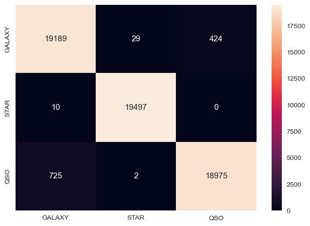

```python
test_and_conf("Bagging Classifier", BaggingClassifier(n_estimators = 20), x_train, x_test, y_train, y_test)
```

- 19189 are the true positives, instances that are predicted to belong to *galaxy* and actually belong to it
- 29 are the false positives, instances that are predicted to belong to *galaxy* but actually belong to *star*
- 424 are the false negatives, instances that are predicted to belong to *galaxy* but actually belong to *qso*
- 10 are the false negatives, instance that are predicted to belong to *star* but actually belong to class *galaxy*
- 19497 are the true positives, instances that are predicted to belong to *star* and actually belong to it
- 0 false positives
- 725 are the false positives, instances that are predicted to belong to *qso* but actually belong to *galaxy*
- 2 are the false negatives, instances that are predicted to belong to *qso* but actually belong to *star*
- 18975 are the true positives, instances that are predicted to belong to *qso* and acutally belong to it

#### XGBoost

```python
evaluate_model_cv(XGBClassifier(), x_train, y_train)
```

[output not shown]

```python
param_grid_xgb = {
    'max_depth': [10, 20]
}

grid_search(param_grid_xgb, XGBClassifier(), x_train, y_train)
```

[output not shown]

[output cut: 15 more lines]

```
XGBClassifier(base_score=0.5, booster='gbtree', colsample_bylevel=1,
              colsample_bynode=1, colsample_bytree=1, enable_categorical=False,
              gamma=0, gpu_id=-1, importance_type=None,
              interaction_constraints='', learning_rate=0.300000012,
              max_delta_step=0, max_depth=20, min_child_weight=1, missing=nan,
              monotone_constraints='()', n_estimators=100, n_jobs=16,
              num_parallel_tree=1, objective='multi:softprob', predictor='auto',
              random_state=0, reg_alpha=0, reg_lambda=1, scale_pos_weight=None,
              subsample=1, tree_method='exact', validate_parameters=1,
              verbosity=None)
```

```
[20:13:33] WARNING: ..\src\learner.cc:1115: Starting in XGBoost 1.3.0, the default evaluation metric used with the objective 'multi:softprob' was changed from 'merror' to 'mlogloss'. Explicitly set eval_metric if you'd like to restore the old behavior.
Accuracy Score for XGB Classifier is :  98.23282527059864 %
XGB Classifier model classification report:
              precision    recall  f1-score   support

           0       0.97      0.98      0.97     19642
           1       1.00      1.00      1.00     19507
           2       0.98      0.97      0.97     19702

    accuracy                           0.98     58851
   macro avg       0.98      0.98      0.98     58851
weighted avg       0.98      0.98      0.98     58851

XGB Classifier model confusion matrix:
```

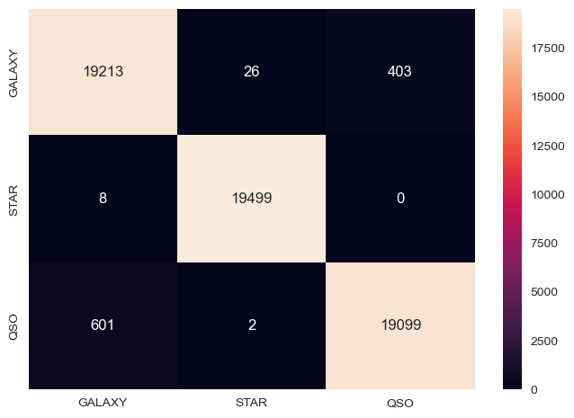

```python
test_and_conf("XGB Classifier", XGBClassifier(max_depth = 20), x_train, x_test, y_train, y_test)
```

- 19213 are the true positives, instances that are predicted to belong to *galaxy* and actually belong to it
- 26 are the false positives, instances that are predicted to belong to *galaxy* but actually belong to *star*
- 403 are the false negatives, instances that are predicted to belong to *galaxy* but actually belong to *qso*
- 8 are the false negatives, instance that are predicted to belong to *star* but actually belong to class *galaxy*
- 19499 are the true positives, instances that are predicted to belong to *star* and actually belong to it
- 0 false positives
- 601 are the false positives, instances that are predicted to belong to *qso* but actually belong to *galaxy*
- 2 are the false negatives, instances that are predicted to belong to *qso* but actually belong to *star*
- 19099 are the true positives, instances that are predicted to belong to *qso* and acutally belong to it

#### AdaBoost

```python
evaluate_model_cv(AdaBoostClassifier(), x_train, y_train)
```

```
Cross-validation scores: [0.66390493 0.65687505 0.68650096 0.66231484 0.66136592 0.59784064
 0.6637931  0.65215936 0.66270506 0.64479411]
Mean score: 0.6552253967544186
Standard deviation: 0.021644297430009826
```

```python
param_grid_ada = {
    'learning_rate': [0.1, 0.5],
    'algorithm': ['SAMME', 'SAMME.R']
}
grid_search(param_grid_ada, AdaBoostClassifier(), x_train, y_train)
```

```
Fitting 10 folds for each of 4 candidates, totalling 40 fits
[CV 1/10] END algorithm=SAMME, learning_rate=0.1;, score=0.932 total time=   4.2s
[CV 2/10] END algorithm=SAMME, learning_rate=0.1;, score=0.934 total time=   4.2s
[CV 3/10] END algorithm=SAMME, learning_rate=0.1;, score=0.931 total time=   4.2s
[CV 4/10] END algorithm=SAMME, learning_rate=0.1;, score=0.928 total time=   4.2s
[CV 5/10] END algorithm=SAMME, learning_rate=0.1;, score=0.929 total time=   4.2s
[CV 6/10] END algorithm=SAMME, learning_rate=0.1;, score=0.928 total time=   4.2s
[CV 7/10] END algorithm=SAMME, learning_rate=0.1;, score=0.931 total time=   4.2s
[CV 8/10] END algorithm=SAMME, learning_rate=0.1;, score=0.931 total time=   4.2s
[CV 9/10] END algorithm=SAMME, learning_rate=0.1;, score=0.930 total time=   4.2s
[CV 10/10] END algorithm=SAMME, learning_rate=0.1;, score=0.928 total time=   4.2s
[CV 1/10] END algorithm=SAMME, learning_rate=0.5;, score=0.944 total time=   4.2s
[CV 2/10] END algorithm=SAMME, learning_rate=0.5;, score=0.932 total time=   4.2s
[CV 3/10] END algorithm=SAMME, learning_rate=0.5;, score=0.944 total time=   4.2s
[CV 4/10] END algorithm=SAMME, learning_rate=0.5;, score=0.941 total time=   4.2s
[CV 5/10] END algorithm=SAMME, learning_rate=0.5;, score=0.942 total time=   4.2s
[CV 6/10] END algorithm=SAMME, learning_rate=0.5;, score=0.943 total time=   4.2s
[CV 7/10] END algorithm=SAMME, learning_rate=0.5;, score=0.946 total time=   4.2s
[CV 8/10] END algorithm=SAMME, learning_rate=0.5;, score=0.945 total time=   4.2s
[CV 9/10] END algorithm=SAMME, learning_rate=0.5;, score=0.944 total time=   4.2s
[CV 10/10] END algorithm=SAMME, learning_rate=0.5;, score=0.942 total time=   4.2s
[CV 1/10] END algorithm=SAMME.R, learning_rate=0.1;, score=0.650 total time=   4.6s
[CV 2/10] END algorithm=SAMME.R, learning_rate=0.1;, score=0.650 total time=   4.6s
[CV 3/10] END algorithm=SAMME.R, learning_rate=0.1;, score=0.664 total time=   4.7s
[CV 4/10] END algorithm=SAMME.R, learning_rate=0.1;, score=0.651 total time=   4.6s
[CV 5/10] END algorithm=SAMME.R, learning_rate=0.1;, score=0.650 total time=   4.6s
[CV 6/10] END algorithm=SAMME.R, learning_rate=0.1;, score=0.649 total time=   4.6s
[CV 7/10] END algorithm=SAMME.R, learning_rate=0.1;, score=0.649 total time=   4.6s
[CV 8/10] END algorithm=SAMME.R, learning_rate=0.1;, score=0.650 total time=   4.6s
[CV 9/10] END algorithm=SAMME.R, learning_rate=0.1;, score=0.650 total time=   4.6s
[CV 10/10] END algorithm=SAMME.R, learning_rate=0.1;, score=0.648 total time=   4.6s
[CV 1/10] END algorithm=SAMME.R, learning_rate=0.5;, score=0.664 total time=   4.6s
[CV 2/10] END algorithm=SAMME.R, learning_rate=0.5;, score=0.664 total time=   4.6s
[CV 3/10] END algorithm=SAMME.R, learning_rate=0.5;, score=0.664 total time=   4.6s
[CV 4/10] END algorithm=SAMME.R, learning_rate=0.5;, score=0.664 total time=   4.6s
[CV 5/10] END algorithm=SAMME.R, learning_rate=0.5;, score=0.664 total time=   4.6s
[CV 6/10] END algorithm=SAMME.R, learning_rate=0.5;, score=0.663 total time=   4.6s
[CV 7/10] END algorithm=SAMME.R, learning_rate=0.5;, score=0.665 total time=   4.7s
[CV 8/10] END algorithm=SAMME.R, learning_rate=0.5;, score=0.665 total time=   4.6s
[CV 9/10] END algorithm=SAMME.R, learning_rate=0.5;, score=0.662 total time=   4.6s
[CV 10/10] END algorithm=SAMME.R, learning_rate=0.5;, score=0.652 total time=   4.6s
Best: 0.942210 using {'algorithm': 'SAMME', 'learning_rate': 0.5}
```

```
AdaBoostClassifier(algorithm='SAMME', learning_rate=0.5)
```

```
Accuracy Score for AdaBoost Classifier is :  94.27707260709248 %
AdaBoost Classifier model classification report:
              precision    recall  f1-score   support

           0       0.90      0.93      0.92     19642
           1       0.99      1.00      1.00     19507
           2       0.93      0.90      0.92     19702

    accuracy                           0.94     58851
   macro avg       0.94      0.94      0.94     58851
weighted avg       0.94      0.94      0.94     58851

AdaBoost Classifier model confusion matrix:
```

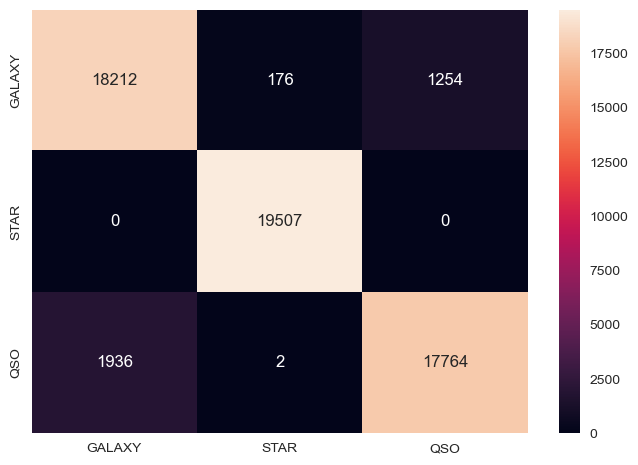

```python
test_and_conf("AdaBoost Classifier", AdaBoostClassifier(algorithm = "SAMME", learning_rate = 0.5), x_train, x_test, y_train, y_test)
```

- 18212 are the true positives, instances that are predicted to belong to *galaxy* and actually belong to it
- 176 are the false positives, instances that are predicted to belong to *galaxy* but actually belong to *star*
- 1254 are the false negatives, instances that are predicted to belong to *galaxy* but actually belong to *qso*
- 0 false negatives
- 19507 are the true positives, instances that are predicted to belong to *star* and actually belong to it
- 0 false positives
- 1936 are the false positives, instances that are predicted to belong to *qso* but actually belong to *galaxy*
- 2 are the false negatives, instances that are predicted to belong to *qso* but actually belong to *star*
- 17764 are the true positives, instances that are predicted to belong to *qso* and acutally belong to it

#### RandomForest

```python
evaluate_model_cv(RandomForestClassifier(), x_train, y_train)
```

```
Cross-validation scores: [0.98133735 0.98242531 0.9786593  0.98158842 0.98225644 0.97849012
 0.98292601 0.9810847  0.98074992 0.98234014]
Mean score: 0.9811857715904131
Standard deviation: 0.0014518487253478863
```

```python
param_grid_rf = {
    'n_estimators': [50],
    'max_depth': [None, 20],
    'min_samples_split': [2, 5],
    'min_samples_leaf': [1, 2],
    'max_features': ['auto']
}
grid_search(param_grid_rf, RandomForestClassifier(), x_train, y_train)
```

```
Fitting 10 folds for each of 8 candidates, totalling 80 fits
[CV 1/10] END max_depth=None, max_features=auto, min_samples_leaf=1, min_samples_split=2, n_estimators=50;, score=0.981 total time=   8.9s
[CV 2/10] END max_depth=None, max_features=auto, min_samples_leaf=1, min_samples_split=2, n_estimators=50;, score=0.982 total time=   8.8s
[CV 3/10] END max_depth=None, max_features=auto, min_samples_leaf=1, min_samples_split=2, n_estimators=50;, score=0.979 total time=   8.9s
[CV 4/10] END max_depth=None, max_features=auto, min_samples_leaf=1, min_samples_split=2, n_estimators=50;, score=0.981 total time=   9.0s
[CV 5/10] END max_depth=None, max_features=auto, min_samples_leaf=1, min_samples_split=2, n_estimators=50;, score=0.982 total time=   8.9s
[CV 6/10] END max_depth=None, max_features=auto, min_samples_leaf=1, min_samples_split=2, n_estimators=50;, score=0.978 total time=   9.0s
[CV 7/10] END max_depth=None, max_features=auto, min_samples_leaf=1, min_samples_split=2, n_estimators=50;, score=0.983 total time=   9.1s
[CV 8/10] END max_depth=None, max_features=auto, min_samples_leaf=1, min_samples_split=2, n_estimators=50;, score=0.981 total time=   9.0s
[CV 9/10] END max_depth=None, max_features=auto, min_samples_leaf=1, min_samples_split=2, n_estimators=50;, score=0.980 total time=   8.8s
[CV 10/10] END max_depth=None, max_features=auto, min_samples_leaf=1, min_samples_split=2, n_estimators=50;, score=0.982 total time=   8.9s
[CV 1/10] END max_depth=None, max_features=auto, min_samples_leaf=1, min_samples_split=5, n_estimators=50;, score=0.980 total time=   9.0s
[CV 2/10] END max_depth=None, max_features=auto, min_samples_leaf=1, min_samples_split=5, n_estimators=50;, score=0.982 total time=   9.0s
[CV 3/10] END max_depth=None, max_features=auto, min_samples_leaf=1, min_samples_split=5, n_estimators=50;, score=0.978 total time=   8.9s
[CV 4/10] END max_depth=None, max_features=auto, min_samples_leaf=1, min_samples_split=5, n_estimators=50;, score=0.981 total time=   8.9s
[CV 5/10] END max_depth=None, max_features=auto, min_samples_leaf=1, min_samples_split=5, n_estimators=50;, score=0.981 total time=   8.8s
[CV 6/10] END max_depth=None, max_features=auto, min_samples_leaf=1, min_samples_split=5, n_estimators=50;, score=0.978 total time=   8.8s
[CV 7/10] END max_depth=None, max_features=auto, min_samples_leaf=1, min_samples_split=5, n_estimators=50;, score=0.982 total time=   8.8s
[CV 8/10] END max_depth=None, max_features=auto, min_samples_leaf=1, min_samples_split=5, n_estimators=50;, score=0.979 total time=   8.8s
[CV 9/10] END max_depth=None, max_features=auto, min_samples_leaf=1, min_samples_split=5, n_estimators=50;, score=0.980 total time=   8.8s
[CV 10/10] END max_depth=None, max_features=auto, min_samples_leaf=1, min_samples_split=5, n_estimators=50;, score=0.982 total time=   8.8s
[CV 1/10] END max_depth=None, max_features=auto, min_samples_leaf=2, min_samples_split=2, n_estimators=50;, score=0.980 total time=   9.0s
[CV 2/10] END max_depth=None, max_features=auto, min_samples_leaf=2, min_samples_split=2, n_estimators=50;, score=0.981 total time=   8.8s
[CV 3/10] END max_depth=None, max_features=auto, min_samples_leaf=2, min_samples_split=2, n_estimators=50;, score=0.977 total time=   8.7s
[CV 4/10] END max_depth=None, max_features=auto, min_samples_leaf=2, min_samples_split=2, n_estimators=50;, score=0.979 total time=   8.8s
[CV 5/10] END max_depth=None, max_features=auto, min_samples_leaf=2, min_samples_split=2, n_estimators=50;, score=0.980 total time=   8.7s
[CV 6/10] END max_depth=None, max_features=auto, min_samples_leaf=2, min_samples_split=2, n_estimators=50;, score=0.978 total time=   8.8s
[CV 7/10] END max_depth=None, max_features=auto, min_samples_leaf=2, min_samples_split=2, n_estimators=50;, score=0.983 total time=   8.8s
[CV 8/10] END max_depth=None, max_features=auto, min_samples_leaf=2, min_samples_split=2, n_estimators=50;, score=0.979 total time=   8.7s
[CV 9/10] END max_depth=None, max_features=auto, min_samples_leaf=2, min_samples_split=2, n_estimators=50;, score=0.980 total time=   8.7s
[CV 10/10] END max_depth=None, max_features=auto, min_samples_leaf=2, min_samples_split=2, n_estimators=50;, score=0.980 total time=   8.9s
[CV 1/10] END max_depth=None, max_features=auto, min_samples_leaf=2, min_samples_split=5, n_estimators=50;, score=0.980 total time=   8.8s
[CV 2/10] END max_depth=None, max_features=auto, min_samples_leaf=2, min_samples_split=5, n_estimators=50;, score=0.982 total time=   8.8s
[CV 3/10] END max_depth=None, max_features=auto, min_samples_leaf=2, min_samples_split=5, n_estimators=50;, score=0.978 total time=   8.8s
[CV 4/10] END max_depth=None, max_features=auto, min_samples_leaf=2, min_samples_split=5, n_estimators=50;, score=0.979 total time=   8.8s
[CV 5/10] END max_depth=None, max_features=auto, min_samples_leaf=2, min_samples_split=5, n_estimators=50;, score=0.981 total time=   8.7s
[CV 6/10] END max_depth=None, max_features=auto, min_samples_leaf=2, min_samples_split=5, n_estimators=50;, score=0.977 total time=   8.8s
[CV 7/10] END max_depth=None, max_features=auto, min_samples_leaf=2, min_samples_split=5, n_estimators=50;, score=0.983 total time=   8.8s
[CV 8/10] END max_depth=None, max_features=auto, min_samples_leaf=2, min_samples_split=5, n_estimators=50;, score=0.979 total time=   8.8s
[CV 9/10] END max_depth=None, max_features=auto, min_samples_leaf=2, min_samples_split=5, n_estimators=50;, score=0.979 total time=   8.7s
```

[output cut: 27 more lines]

```
[CV 7/10] END max_depth=20, max_features=auto, min_samples_leaf=2, min_samples_split=2, n_estimators=50;, score=0.982 total time=   8.7s
[CV 8/10] END max_depth=20, max_features=auto, min_samples_leaf=2, min_samples_split=2, n_estimators=50;, score=0.979 total time=   8.7s
[CV 9/10] END max_depth=20, max_features=auto, min_samples_leaf=2, min_samples_split=2, n_estimators=50;, score=0.979 total time=   8.6s
[CV 10/10] END max_depth=20, max_features=auto, min_samples_leaf=2, min_samples_split=2, n_estimators=50;, score=0.981 total time=   8.7s
[CV 1/10] END max_depth=20, max_features=auto, min_samples_leaf=2, min_samples_split=5, n_estimators=50;, score=0.980 total time=   8.8s
[CV 2/10] END max_depth=20, max_features=auto, min_samples_leaf=2, min_samples_split=5, n_estimators=50;, score=0.982 total time=   8.6s
[CV 3/10] END max_depth=20, max_features=auto, min_samples_leaf=2, min_samples_split=5, n_estimators=50;, score=0.976 total time=   8.8s
[CV 4/10] END max_depth=20, max_features=auto, min_samples_leaf=2, min_samples_split=5, n_estimators=50;, score=0.980 total time=   8.8s
[CV 5/10] END max_depth=20, max_features=auto, min_samples_leaf=2, min_samples_split=5, n_estimators=50;, score=0.980 total time=   8.6s
[CV 6/10] END max_depth=20, max_features=auto, min_samples_leaf=2, min_samples_split=5, n_estimators=50;, score=0.978 total time=   8.7s
[CV 7/10] END max_depth=20, max_features=auto, min_samples_leaf=2, min_samples_split=5, n_estimators=50;, score=0.981 total time=   8.7s
[CV 8/10] END max_depth=20, max_features=auto, min_samples_leaf=2, min_samples_split=5, n_estimators=50;, score=0.979 total time=   8.8s
[CV 9/10] END max_depth=20, max_features=auto, min_samples_leaf=2, min_samples_split=5, n_estimators=50;, score=0.979 total time=   8.7s
[CV 10/10] END max_depth=20, max_features=auto, min_samples_leaf=2, min_samples_split=5, n_estimators=50;, score=0.980 total time=   8.7s
Best: 0.980893 using {'max_depth': None, 'max_features': 'auto', 'min_samples_leaf': 1, 'min_samples_split': 2, 'n_estimators': 50}
```

```
RandomForestClassifier(n_estimators=50)
```

```
Accuracy Score for RandomForest Classifier is :  98.10198637236411 %
RandomForest Classifier model classification report:
              precision    recall  f1-score   support

           0       0.96      0.98      0.97     19642
           1       1.00      1.00      1.00     19507
           2       0.98      0.96      0.97     19702

    accuracy                           0.98     58851
   macro avg       0.98      0.98      0.98     58851
weighted avg       0.98      0.98      0.98     58851

RandomForest Classifier model confusion matrix:
```

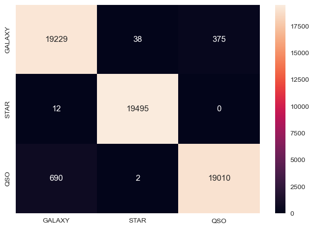

```python
test_and_conf("RandomForest Classifier", RandomForestClassifier(n_estimators = 50, max_depth = None, min_samples_split = 2, min_samples_leaf = 1), x_train, x_test, y_train, y_test)
```

- 19229 are the true positives, instances that are predicted to belong to *galaxy* and actually belong to it
- 38 are the false positives, instances that are predicted to belong to *galaxy* but actually belong to *star*
- 375 are the false negatives, instances that are predicted to belong to *galaxy* but actually belong to *qso*
- 12 are the false negatives, instance that are predicted to belong to *star* but actually belong to class *galaxy*
- 19495 are the true positives, instances that are predicted to belong to *star* and actually belong to it
- 0 false positives
- 690 are the false positives, instances that are predicted to belong to *qso* but actually belong to *galaxy*
- 2 are the false negatives, instances that are predicted to belong to *qso* but actually belong to *star*
- 19010 are the true positives, instances that are predicted to belong to *qso* and acutally belong to it

#### ExtraTrees

```python
evaluate_model_cv(ExtraTreesClassifier(), x_train, y_train)
```

```
Cross-validation scores: [0.98158842 0.98234162 0.98050046 0.98209055 0.98376297 0.98066622
 0.98384667 0.98208905 0.98008035 0.98192166]
Mean score: 0.9818887971120877
Standard deviation: 0.0012006506492205087
```

```python
param_grid_ex = {
    'n_estimators': [50, 200],
    'max_depth': [None]
}
grid_search(param_grid_ex, ExtraTreesClassifier(), x_train, y_train)
```

```
Fitting 10 folds for each of 2 candidates, totalling 20 fits
[CV 1/10] END ..max_depth=None, n_estimators=50;, score=0.981 total time=   2.5s
[CV 2/10] END ..max_depth=None, n_estimators=50;, score=0.982 total time=   2.5s
[CV 3/10] END ..max_depth=None, n_estimators=50;, score=0.980 total time=   2.5s
[CV 4/10] END ..max_depth=None, n_estimators=50;, score=0.983 total time=   2.4s
[CV 5/10] END ..max_depth=None, n_estimators=50;, score=0.983 total time=   2.4s
[CV 6/10] END ..max_depth=None, n_estimators=50;, score=0.980 total time=   2.4s
[CV 7/10] END ..max_depth=None, n_estimators=50;, score=0.984 total time=   2.5s
[CV 8/10] END ..max_depth=None, n_estimators=50;, score=0.982 total time=   2.5s
[CV 9/10] END ..max_depth=None, n_estimators=50;, score=0.979 total time=   2.5s
[CV 10/10] END .max_depth=None, n_estimators=50;, score=0.982 total time=   2.4s
[CV 1/10] END .max_depth=None, n_estimators=200;, score=0.982 total time=  10.0s
[CV 2/10] END .max_depth=None, n_estimators=200;, score=0.982 total time=  10.0s
[CV 3/10] END .max_depth=None, n_estimators=200;, score=0.980 total time=   9.9s
[CV 4/10] END .max_depth=None, n_estimators=200;, score=0.982 total time=   9.8s
[CV 5/10] END .max_depth=None, n_estimators=200;, score=0.983 total time=   9.9s
[CV 6/10] END .max_depth=None, n_estimators=200;, score=0.980 total time=  10.3s
[CV 7/10] END .max_depth=None, n_estimators=200;, score=0.984 total time=  10.2s
[CV 8/10] END .max_depth=None, n_estimators=200;, score=0.982 total time=   9.9s
[CV 9/10] END .max_depth=None, n_estimators=200;, score=0.980 total time=   9.9s
[CV 10/10] END max_depth=None, n_estimators=200;, score=0.983 total time=  10.2s
Best: 0.981839 using {'max_depth': None, 'n_estimators': 50}
```

```
ExtraTreesClassifier(n_estimators=50)
```

```
Accuracy Score for ExtraTrees Classifier is :  98.15296256648145 %
ExtraTrees Classifier model classification report:
              precision    recall  f1-score   support

           0       0.97      0.97      0.97     19642
           1       0.99      1.00      1.00     19507
           2       0.98      0.97      0.98     19702

    accuracy                           0.98     58851
   macro avg       0.98      0.98      0.98     58851
weighted avg       0.98      0.98      0.98     58851

ExtraTrees Classifier model confusion matrix:
```

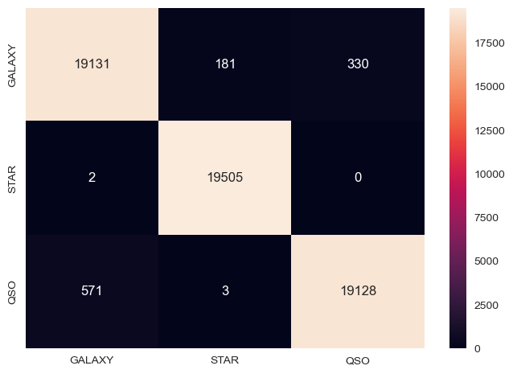

```python
test_and_conf("ExtraTrees Classifier", ExtraTreesClassifier(max_depth = None, n_estimators = 50), x_train, x_test, y_train, y_test)
```

- 19131 are the true positives, instances that are predicted to belong to *galaxy* and actually belong to it
- 181 are the false positives, instances that are predicted to belong to *galaxy* but actually belong to *star*
- 330 are the false negatives, instances that are predicted to belong to *galaxy* but actually belong to *qso*
- 2 are the false negatives, instance that are predicted to belong to *star* but actually belong to class *galaxy*
- 19505 are the true positives, instances that are predicted to belong to *star* and actually belong to it
- 0 false positives
- 571 are the false positives, instances that are predicted to belong to *qso* but actually belong to *galaxy*
- 3 are the false negatives, instances that are predicted to belong to *qso* but actually belong to *star*
- 19128 are the true positives, instances that are predicted to belong to *qso* and acutally belong to it

#### DecisionTree

```python
evaluate_model_cv(DecisionTreeClassifier(), x_train, y_train)
```

```
Cross-validation scores: [0.96836555 0.97054147 0.97020671 0.96995564 0.97204553 0.97045531
 0.97321727 0.97212923 0.96827921 0.97313358]
Mean score: 0.9708329505408588
Standard deviation: 0.001677129440506111
```

```python
param_grid_dt = {
    'max_depth': [None, 5],
    'min_samples_split': [2, 5]
}
grid_search(param_grid_dt, DecisionTreeClassifier(), x_train, y_train)
```

```
Fitting 10 folds for each of 4 candidates, totalling 40 fits
[CV 1/10] END max_depth=None, min_samples_split=2;, score=0.969 total time=   0.7s
[CV 2/10] END max_depth=None, min_samples_split=2;, score=0.969 total time=   0.7s
[CV 3/10] END max_depth=None, min_samples_split=2;, score=0.970 total time=   0.7s
[CV 4/10] END max_depth=None, min_samples_split=2;, score=0.972 total time=   0.7s
[CV 5/10] END max_depth=None, min_samples_split=2;, score=0.972 total time=   0.7s
[CV 6/10] END max_depth=None, min_samples_split=2;, score=0.971 total time=   0.7s
[CV 7/10] END max_depth=None, min_samples_split=2;, score=0.974 total time=   0.7s
[CV 8/10] END max_depth=None, min_samples_split=2;, score=0.972 total time=   0.7s
[CV 9/10] END max_depth=None, min_samples_split=2;, score=0.969 total time=   0.7s
[CV 10/10] END max_depth=None, min_samples_split=2;, score=0.972 total time=   0.7s
[CV 1/10] END max_depth=None, min_samples_split=5;, score=0.968 total time=   0.7s
[CV 2/10] END max_depth=None, min_samples_split=5;, score=0.969 total time=   0.7s
[CV 3/10] END max_depth=None, min_samples_split=5;, score=0.970 total time=   0.7s
[CV 4/10] END max_depth=None, min_samples_split=5;, score=0.969 total time=   0.7s
[CV 5/10] END max_depth=None, min_samples_split=5;, score=0.972 total time=   0.7s
[CV 6/10] END max_depth=None, min_samples_split=5;, score=0.970 total time=   0.7s
[CV 7/10] END max_depth=None, min_samples_split=5;, score=0.973 total time=   0.7s
[CV 8/10] END max_depth=None, min_samples_split=5;, score=0.971 total time=   0.7s
[CV 9/10] END max_depth=None, min_samples_split=5;, score=0.968 total time=   0.7s
[CV 10/10] END max_depth=None, min_samples_split=5;, score=0.972 total time=   0.7s
[CV 1/10] END .max_depth=5, min_samples_split=2;, score=0.962 total time=   0.2s
[CV 2/10] END .max_depth=5, min_samples_split=2;, score=0.964 total time=   0.2s
[CV 3/10] END .max_depth=5, min_samples_split=2;, score=0.960 total time=   0.2s
[CV 4/10] END .max_depth=5, min_samples_split=2;, score=0.964 total time=   0.2s
[CV 5/10] END .max_depth=5, min_samples_split=2;, score=0.960 total time=   0.2s
[CV 6/10] END .max_depth=5, min_samples_split=2;, score=0.962 total time=   0.2s
[CV 7/10] END .max_depth=5, min_samples_split=2;, score=0.963 total time=   0.2s
[CV 8/10] END .max_depth=5, min_samples_split=2;, score=0.961 total time=   0.2s
[CV 9/10] END .max_depth=5, min_samples_split=2;, score=0.959 total time=   0.2s
[CV 10/10] END max_depth=5, min_samples_split=2;, score=0.965 total time=   0.2s
[CV 1/10] END .max_depth=5, min_samples_split=5;, score=0.962 total time=   0.2s
[CV 2/10] END .max_depth=5, min_samples_split=5;, score=0.964 total time=   0.3s
[CV 3/10] END .max_depth=5, min_samples_split=5;, score=0.960 total time=   0.3s
[CV 4/10] END .max_depth=5, min_samples_split=5;, score=0.964 total time=   0.2s
[CV 5/10] END .max_depth=5, min_samples_split=5;, score=0.960 total time=   0.2s
[CV 6/10] END .max_depth=5, min_samples_split=5;, score=0.962 total time=   0.2s
[CV 7/10] END .max_depth=5, min_samples_split=5;, score=0.963 total time=   0.3s
[CV 8/10] END .max_depth=5, min_samples_split=5;, score=0.961 total time=   0.2s
[CV 9/10] END .max_depth=5, min_samples_split=5;, score=0.959 total time=   0.2s
[CV 10/10] END max_depth=5, min_samples_split=5;, score=0.965 total time=   0.2s
Best: 0.971025 using {'max_depth': None, 'min_samples_split': 2}
```

```
DecisionTreeClassifier()
```

```
Accuracy Score for DecisionTree Classifier is :  97.00769740531172 %
DecisionTree Classifier model classification report:
              precision    recall  f1-score   support

           0       0.96      0.95      0.96     19642
           1       1.00      1.00      1.00     19507
           2       0.96      0.96      0.96     19702

    accuracy                           0.97     58851
   macro avg       0.97      0.97      0.97     58851
weighted avg       0.97      0.97      0.97     58851

DecisionTree Classifier model confusion matrix:
```

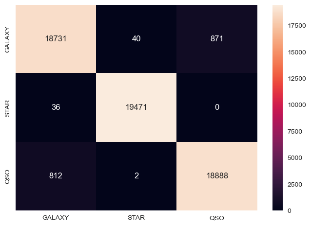

```python
test_and_conf("DecisionTree Classifier", DecisionTreeClassifier(max_depth = None, min_samples_split = 2), x_train, x_test, y_train, y_test)
```

- 18731 are the true positives, instances that are predicted to belong to *galaxy* and actually belong to it
- 40 are the false positives, instances that are predicted to belong to *galaxy* but actually belong to *star*
- 871 are the false negatives, instances that are predicted to belong to *galaxy* but actually belong to *qso*
- 36 are the false negatives, instance that are predicted to belong to *star* but actually belong to class *galaxy*
- 19471 are the true positives, instances that are predicted to belong to *star* and actually belong to it
- 0 false positives
- 812 are the false positives, instances that are predicted to belong to *qso* but actually belong to *galaxy*
- 2 are the false negatives, instances that are predicted to belong to *qso* but actually belong to *star*
- 18888 are the true positives, instances that are predicted to belong to *qso* and acutally belong to it

#### GaussianNB

```python
evaluate_model_cv(GaussianNB(), x_train, y_train)
```

```
Cross-validation scores: [0.92292242 0.91990962 0.9223366  0.91949117 0.91580181 0.91898226
 0.92157683 0.9202377  0.9179779  0.92258119]
Mean score: 0.920181748746199
Standard deviation: 0.0021422391642074634
```

```python
param_grid_gaus = {
    'var_smoothing': [1e-9, 1e-8, 1e-7, 1e-6, 1e-5, 1e-4, 1e-3, 1e-2]
}
grid_search(param_grid_gaus, GaussianNB(), x_train, y_train)
```

```
Fitting 10 folds for each of 8 candidates, totalling 80 fits
[CV 1/10] END ..............var_smoothing=1e-09;, score=0.923 total time=   0.0s
[CV 2/10] END ..............var_smoothing=1e-09;, score=0.920 total time=   0.0s
[CV 3/10] END ..............var_smoothing=1e-09;, score=0.922 total time=   0.0s
[CV 4/10] END ..............var_smoothing=1e-09;, score=0.919 total time=   0.0s
[CV 5/10] END ..............var_smoothing=1e-09;, score=0.916 total time=   0.0s
[CV 6/10] END ..............var_smoothing=1e-09;, score=0.919 total time=   0.0s
[CV 7/10] END ..............var_smoothing=1e-09;, score=0.922 total time=   0.0s
[CV 8/10] END ..............var_smoothing=1e-09;, score=0.920 total time=   0.0s
[CV 9/10] END ..............var_smoothing=1e-09;, score=0.918 total time=   0.0s
[CV 10/10] END .............var_smoothing=1e-09;, score=0.923 total time=   0.0s
[CV 1/10] END ..............var_smoothing=1e-08;, score=0.923 total time=   0.0s
[CV 2/10] END ..............var_smoothing=1e-08;, score=0.920 total time=   0.0s
[CV 3/10] END ..............var_smoothing=1e-08;, score=0.922 total time=   0.0s
[CV 4/10] END ..............var_smoothing=1e-08;, score=0.920 total time=   0.0s
[CV 5/10] END ..............var_smoothing=1e-08;, score=0.916 total time=   0.0s
[CV 6/10] END ..............var_smoothing=1e-08;, score=0.919 total time=   0.0s
[CV 7/10] END ..............var_smoothing=1e-08;, score=0.922 total time=   0.0s
[CV 8/10] END ..............var_smoothing=1e-08;, score=0.920 total time=   0.0s
[CV 9/10] END ..............var_smoothing=1e-08;, score=0.918 total time=   0.0s
[CV 10/10] END .............var_smoothing=1e-08;, score=0.923 total time=   0.0s
[CV 1/10] END ..............var_smoothing=1e-07;, score=0.924 total time=   0.0s
[CV 2/10] END ..............var_smoothing=1e-07;, score=0.920 total time=   0.0s
[CV 3/10] END ..............var_smoothing=1e-07;, score=0.923 total time=   0.0s
[CV 4/10] END ..............var_smoothing=1e-07;, score=0.920 total time=   0.0s
[CV 5/10] END ..............var_smoothing=1e-07;, score=0.917 total time=   0.0s
[CV 6/10] END ..............var_smoothing=1e-07;, score=0.920 total time=   0.0s
[CV 7/10] END ..............var_smoothing=1e-07;, score=0.923 total time=   0.0s
[CV 8/10] END ..............var_smoothing=1e-07;, score=0.921 total time=   0.0s
[CV 9/10] END ..............var_smoothing=1e-07;, score=0.919 total time=   0.0s
[CV 10/10] END .............var_smoothing=1e-07;, score=0.923 total time=   0.0s
[CV 1/10] END ..............var_smoothing=1e-06;, score=0.925 total time=   0.0s
[CV 2/10] END ..............var_smoothing=1e-06;, score=0.923 total time=   0.0s
[CV 3/10] END ..............var_smoothing=1e-06;, score=0.924 total time=   0.0s
[CV 4/10] END ..............var_smoothing=1e-06;, score=0.922 total time=   0.0s
[CV 5/10] END ..............var_smoothing=1e-06;, score=0.919 total time=   0.0s
[CV 6/10] END ..............var_smoothing=1e-06;, score=0.922 total time=   0.0s
[CV 7/10] END ..............var_smoothing=1e-06;, score=0.924 total time=   0.0s
[CV 8/10] END ..............var_smoothing=1e-06;, score=0.923 total time=   0.0s
[CV 9/10] END ..............var_smoothing=1e-06;, score=0.921 total time=   0.0s
```

[output cut: 27 more lines]

```
[CV 7/10] END ..............var_smoothing=0.001;, score=0.887 total time=   0.0s
[CV 8/10] END ..............var_smoothing=0.001;, score=0.884 total time=   0.0s
[CV 9/10] END ..............var_smoothing=0.001;, score=0.885 total time=   0.0s
[CV 10/10] END .............var_smoothing=0.001;, score=0.886 total time=   0.0s
[CV 1/10] END ...............var_smoothing=0.01;, score=0.784 total time=   0.0s
[CV 2/10] END ...............var_smoothing=0.01;, score=0.785 total time=   0.0s
[CV 3/10] END ...............var_smoothing=0.01;, score=0.783 total time=   0.0s
[CV 4/10] END ...............var_smoothing=0.01;, score=0.779 total time=   0.0s
[CV 5/10] END ...............var_smoothing=0.01;, score=0.777 total time=   0.0s
[CV 6/10] END ...............var_smoothing=0.01;, score=0.780 total time=   0.0s
[CV 7/10] END ...............var_smoothing=0.01;, score=0.779 total time=   0.0s
[CV 8/10] END ...............var_smoothing=0.01;, score=0.774 total time=   0.0s
[CV 9/10] END ...............var_smoothing=0.01;, score=0.782 total time=   0.0s
[CV 10/10] END ..............var_smoothing=0.01;, score=0.780 total time=   0.0s
Best: 0.922927 using {'var_smoothing': 1e-05}
```

```
GaussianNB(var_smoothing=1e-05)
```

```
Accuracy Score for GaussianNB is :  92.19044706122241 %
GaussianNB model classification report:
              precision    recall  f1-score   support

           0       0.90      0.86      0.88     19642
           1       0.99      1.00      0.99     19507
           2       0.87      0.91      0.89     19702

    accuracy                           0.92     58851
   macro avg       0.92      0.92      0.92     58851
weighted avg       0.92      0.92      0.92     58851

GaussianNB model confusion matrix:
```

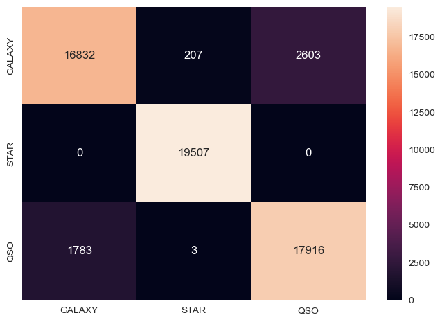

```python
test_and_conf("GaussianNB", GaussianNB(var_smoothing = 1e-05), x_train, x_test, y_train, y_test)
```

### 4.2 Achieved results and further application

The results obtained by the supervised learning techniques outline that all the method with the function *grid_search* applied have an accuracy above the 90%, that is very solid. By considering all the machine learning models used, the best results are achieved by the *XGB Classifier*, with an accuracy of *98,23%*.

Is important to notice that these results have been carried out with the balanced dataset thanks to the *SMOTE* technique. It would be nice to discover the behaviour of the machine learning models with the imbalanced dataset.

Data preparation:

```python
imbalanced_data = data.copy()
xi = imbalanced_data.drop(['class'], axis = 1)
yi = imbalanced_data.loc[:,'class'].values
Counter(yi)
```

```
Counter({0: 59445, 2: 18961, 1: 21593})
```

As it possible to notice, the dataset now is the original one, because it is imbalanced.

```python
scaler = StandardScaler()
scaler.fit(xi)
xi = scaler.transform(xi)
```

Of course the *train_test_split* should be implemented another time, in such a way that the new *xi* and *yi* are used.

```python
xi_train, xi_test, yi_train, yi_test = train_test_split(xi, yi, test_size = 0.33, random_state = 42)
```

Everything is ready for this experiment. I will use the same framework of before.

#### Logistic Regression

```python
evaluate_model_cv(LogisticRegression(), xi_train, yi_train)
```

```
Cross-validation scores: [0.95641791 0.95865672 0.95671642 0.95567164 0.95880597 0.95955224
 0.95641791 0.9538806  0.95402985 0.95118674]
Mean score: 0.9561335998021535
Standard deviation: 0.00244709382146646
```

```python
param_grid_logreg = {'C': [0.1, 1, 10], 'penalty': ['l1', 'l2']}
grid_search(param_grid_logreg, LogisticRegression(), xi_train, yi_train)
```

```
Fitting 10 folds for each of 6 candidates, totalling 60 fits
[CV 1/10] END ..................C=0.1, penalty=l1;, score=nan total time=   0.0s
[CV 2/10] END ..................C=0.1, penalty=l1;, score=nan total time=   0.0s
[CV 3/10] END ..................C=0.1, penalty=l1;, score=nan total time=   0.0s
[CV 4/10] END ..................C=0.1, penalty=l1;, score=nan total time=   0.0s
[CV 5/10] END ..................C=0.1, penalty=l1;, score=nan total time=   0.0s
[CV 6/10] END ..................C=0.1, penalty=l1;, score=nan total time=   0.0s
[CV 7/10] END ..................C=0.1, penalty=l1;, score=nan total time=   0.0s
[CV 8/10] END ..................C=0.1, penalty=l1;, score=nan total time=   0.0s
[CV 9/10] END ..................C=0.1, penalty=l1;, score=nan total time=   0.0s
[CV 10/10] END .................C=0.1, penalty=l1;, score=nan total time=   0.0s
[CV 1/10] END ................C=0.1, penalty=l2;, score=0.953 total time=   1.0s
[CV 2/10] END ................C=0.1, penalty=l2;, score=0.953 total time=   1.0s
[CV 3/10] END ................C=0.1, penalty=l2;, score=0.951 total time=   0.9s
[CV 4/10] END ................C=0.1, penalty=l2;, score=0.950 total time=   0.9s
[CV 5/10] END ................C=0.1, penalty=l2;, score=0.954 total time=   1.1s
[CV 6/10] END ................C=0.1, penalty=l2;, score=0.953 total time=   1.1s
[CV 7/10] END ................C=0.1, penalty=l2;, score=0.951 total time=   0.9s
[CV 8/10] END ................C=0.1, penalty=l2;, score=0.946 total time=   0.8s
[CV 9/10] END ................C=0.1, penalty=l2;, score=0.949 total time=   0.8s
[CV 10/10] END ...............C=0.1, penalty=l2;, score=0.946 total time=   1.0s
[CV 1/10] END ....................C=1, penalty=l1;, score=nan total time=   0.0s
[CV 2/10] END ....................C=1, penalty=l1;, score=nan total time=   0.0s
[CV 3/10] END ....................C=1, penalty=l1;, score=nan total time=   0.0s
[CV 4/10] END ....................C=1, penalty=l1;, score=nan total time=   0.0s
[CV 5/10] END ....................C=1, penalty=l1;, score=nan total time=   0.0s
[CV 6/10] END ....................C=1, penalty=l1;, score=nan total time=   0.0s
[CV 7/10] END ....................C=1, penalty=l1;, score=nan total time=   0.0s
[CV 8/10] END ....................C=1, penalty=l1;, score=nan total time=   0.0s
[CV 9/10] END ....................C=1, penalty=l1;, score=nan total time=   0.0s
[CV 10/10] END ...................C=1, penalty=l1;, score=nan total time=   0.0s
[CV 1/10] END ..................C=1, penalty=l2;, score=0.956 total time=   0.9s
[CV 2/10] END ..................C=1, penalty=l2;, score=0.959 total time=   1.0s
[CV 3/10] END ..................C=1, penalty=l2;, score=0.957 total time=   1.1s
[CV 4/10] END ..................C=1, penalty=l2;, score=0.956 total time=   1.0s
[CV 5/10] END ..................C=1, penalty=l2;, score=0.959 total time=   1.2s
[CV 6/10] END ..................C=1, penalty=l2;, score=0.960 total time=   1.1s
[CV 7/10] END ..................C=1, penalty=l2;, score=0.956 total time=   1.0s
[CV 8/10] END ..................C=1, penalty=l2;, score=0.954 total time=   1.0s
[CV 9/10] END ..................C=1, penalty=l2;, score=0.954 total time=   0.9s
[CV 10/10] END .................C=1, penalty=l2;, score=0.951 total time=   1.0s
[CV 1/10] END ...................C=10, penalty=l1;, score=nan total time=   0.0s
[CV 2/10] END ...................C=10, penalty=l1;, score=nan total time=   0.0s
[CV 3/10] END ...................C=10, penalty=l1;, score=nan total time=   0.0s
[CV 4/10] END ...................C=10, penalty=l1;, score=nan total time=   0.0s
[CV 5/10] END ...................C=10, penalty=l1;, score=nan total time=   0.0s
[CV 6/10] END ...................C=10, penalty=l1;, score=nan total time=   0.0s
[CV 7/10] END ...................C=10, penalty=l1;, score=nan total time=   0.0s
[CV 8/10] END ...................C=10, penalty=l1;, score=nan total time=   0.0s
[CV 9/10] END ...................C=10, penalty=l1;, score=nan total time=   0.0s
[CV 10/10] END ..................C=10, penalty=l1;, score=nan total time=   0.0s
[CV 1/10] END .................C=10, penalty=l2;, score=0.961 total time=   1.0s
[CV 2/10] END .................C=10, penalty=l2;, score=0.962 total time=   1.2s
[CV 3/10] END .................C=10, penalty=l2;, score=0.960 total time=   1.1s
[CV 4/10] END .................C=10, penalty=l2;, score=0.959 total time=   1.1s
[CV 5/10] END .................C=10, penalty=l2;, score=0.962 total time=   1.0s
[CV 6/10] END .................C=10, penalty=l2;, score=0.963 total time=   1.1s
[CV 7/10] END .................C=10, penalty=l2;, score=0.959 total time=   1.1s
[CV 8/10] END .................C=10, penalty=l2;, score=0.958 total time=   1.2s
[CV 9/10] END .................C=10, penalty=l2;, score=0.958 total time=   1.0s
[CV 10/10] END ................C=10, penalty=l2;, score=0.956 total time=   1.2s
Best: 0.959895 using {'C': 10, 'penalty': 'l2'}
```

```
LogisticRegression(C=10)
```

```
Accuracy Score for Logistic Regression is :  95.77878787878788 %
Logistic Regression model classification report:
              precision    recall  f1-score   support

           0       0.96      0.97      0.96     19590
           1       0.96      1.00      0.98      7104
           2       0.94      0.87      0.91      6306

    accuracy                           0.96     33000
   macro avg       0.96      0.95      0.95     33000
weighted avg       0.96      0.96      0.96     33000

Logistic Regression model confusion matrix:
```

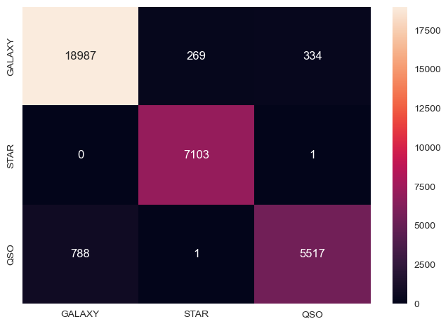

```python
test_and_conf("Logistic Regression", LogisticRegression(penalty = 'l2', C = 10), xi_train, xi_test, yi_train, yi_test)
```

- 18987 are the true positives, instances that are predicted to belong to *galaxy* and actually belong to it
- 269 are the false positives, instances that are predicted to belong to *galaxy* but actually belong to *star*
- 334 are the false negatives, instances that are predicted to belong to *galaxy* but actually belong to *qso*
- 0 false negative
- 7103 are the true positives, instances that are predicted to belong to *star* and actually belong to it
- 1 is the false positive, instance that is predicetd to belong to *star* but actualy belong to *qso*
- 788 are the false positives, instances that are predicted to belong to *qso* but actually belong to *galaxy*
- 1 is the false negative, instance that is predicted to belong to *qso* but actually belong to *star*
- 5517 are the true positives, instances that are predicted to belong to *qso* and acutally belong to it

#### K-nearest Neighbors

```python
evaluate_model_cv(KNeighborsClassifier(), xi_train, yi_train)
```

```
Cross-validation scores: [0.96134328 0.96402985 0.96537313 0.96313433 0.96597015 0.96208955
 0.96253731 0.95671642 0.96179104 0.9595462 ]
Mean score: 0.9622531275552376
Standard deviation: 0.0025809961883143237
```

```python
param_grid_knn = {"n_neighbors": list(range(2, 30, 3))}
grid_search(param_grid_knn, KNeighborsClassifier(), xi_train, yi_train)
```

```
Fitting 10 folds for each of 10 candidates, totalling 100 fits
[CV 1/10] END ....................n_neighbors=2;, score=0.951 total time=   0.2s
[CV 2/10] END ....................n_neighbors=2;, score=0.956 total time=   0.2s
[CV 3/10] END ....................n_neighbors=2;, score=0.956 total time=   0.2s
[CV 4/10] END ....................n_neighbors=2;, score=0.953 total time=   0.2s
[CV 5/10] END ....................n_neighbors=2;, score=0.957 total time=   0.2s
[CV 6/10] END ....................n_neighbors=2;, score=0.951 total time=   0.2s
[CV 7/10] END ....................n_neighbors=2;, score=0.953 total time=   0.2s
[CV 8/10] END ....................n_neighbors=2;, score=0.946 total time=   0.2s
[CV 9/10] END ....................n_neighbors=2;, score=0.955 total time=   0.2s
[CV 10/10] END ...................n_neighbors=2;, score=0.952 total time=   0.2s
[CV 1/10] END ....................n_neighbors=5;, score=0.961 total time=   0.2s
[CV 2/10] END ....................n_neighbors=5;, score=0.964 total time=   0.2s
[CV 3/10] END ....................n_neighbors=5;, score=0.965 total time=   0.2s
[CV 4/10] END ....................n_neighbors=5;, score=0.963 total time=   0.2s
[CV 5/10] END ....................n_neighbors=5;, score=0.966 total time=   0.2s
[CV 6/10] END ....................n_neighbors=5;, score=0.962 total time=   0.2s
[CV 7/10] END ....................n_neighbors=5;, score=0.963 total time=   0.2s
[CV 8/10] END ....................n_neighbors=5;, score=0.957 total time=   0.2s
[CV 9/10] END ....................n_neighbors=5;, score=0.962 total time=   0.2s
[CV 10/10] END ...................n_neighbors=5;, score=0.960 total time=   0.2s
[CV 1/10] END ....................n_neighbors=8;, score=0.961 total time=   0.2s
[CV 2/10] END ....................n_neighbors=8;, score=0.963 total time=   0.2s
[CV 3/10] END ....................n_neighbors=8;, score=0.963 total time=   0.2s
[CV 4/10] END ....................n_neighbors=8;, score=0.961 total time=   0.2s
[CV 5/10] END ....................n_neighbors=8;, score=0.965 total time=   0.2s
[CV 6/10] END ....................n_neighbors=8;, score=0.962 total time=   0.2s
[CV 7/10] END ....................n_neighbors=8;, score=0.962 total time=   0.2s
[CV 8/10] END ....................n_neighbors=8;, score=0.957 total time=   0.2s
[CV 9/10] END ....................n_neighbors=8;, score=0.962 total time=   0.2s
[CV 10/10] END ...................n_neighbors=8;, score=0.958 total time=   0.2s
[CV 1/10] END ...................n_neighbors=11;, score=0.959 total time=   0.2s
[CV 2/10] END ...................n_neighbors=11;, score=0.964 total time=   0.2s
[CV 3/10] END ...................n_neighbors=11;, score=0.961 total time=   0.2s
[CV 4/10] END ...................n_neighbors=11;, score=0.960 total time=   0.2s
[CV 5/10] END ...................n_neighbors=11;, score=0.963 total time=   0.2s
[CV 6/10] END ...................n_neighbors=11;, score=0.961 total time=   0.2s
[CV 7/10] END ...................n_neighbors=11;, score=0.961 total time=   0.2s
[CV 8/10] END ...................n_neighbors=11;, score=0.955 total time=   0.2s
[CV 9/10] END ...................n_neighbors=11;, score=0.960 total time=   0.2s
```

[output cut: 47 more lines]

```
[CV 7/10] END ...................n_neighbors=26;, score=0.957 total time=   0.3s
[CV 8/10] END ...................n_neighbors=26;, score=0.950 total time=   0.3s
[CV 9/10] END ...................n_neighbors=26;, score=0.956 total time=   0.3s
[CV 10/10] END ..................n_neighbors=26;, score=0.955 total time=   0.2s
[CV 1/10] END ...................n_neighbors=29;, score=0.954 total time=   0.3s
[CV 2/10] END ...................n_neighbors=29;, score=0.960 total time=   0.3s
[CV 3/10] END ...................n_neighbors=29;, score=0.956 total time=   0.3s
[CV 4/10] END ...................n_neighbors=29;, score=0.953 total time=   0.3s
[CV 5/10] END ...................n_neighbors=29;, score=0.958 total time=   0.3s
[CV 6/10] END ...................n_neighbors=29;, score=0.957 total time=   0.3s
[CV 7/10] END ...................n_neighbors=29;, score=0.957 total time=   0.3s
[CV 8/10] END ...................n_neighbors=29;, score=0.949 total time=   0.3s
[CV 9/10] END ...................n_neighbors=29;, score=0.956 total time=   0.3s
[CV 10/10] END ..................n_neighbors=29;, score=0.954 total time=   0.3s
Best: 0.962253 using {'n_neighbors': 5}
```

```
KNeighborsClassifier()
```

```
Accuracy Score for KNN Classifier is :  96.14545454545454 %
KNN Classifier model classification report:
              precision    recall  f1-score   support

           0       0.97      0.97      0.97     19590
           1       0.94      0.98      0.96      7104
           2       0.96      0.92      0.94      6306

    accuracy                           0.96     33000
   macro avg       0.96      0.96      0.96     33000
weighted avg       0.96      0.96      0.96     33000

KNN Classifier model confusion matrix:
```

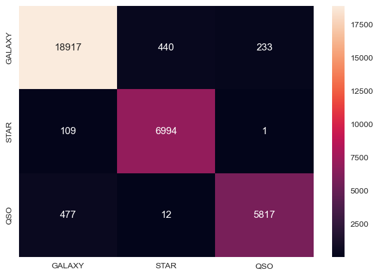

```python
test_and_conf("KNN Classifier", KNeighborsClassifier(n_neighbors = 5), xi_train, xi_test, yi_train, yi_test)
```

- 18917 are the true positives, instances that are predicted to belong to *galaxy* and actually belong to it
- 440 are the false positives, instances that are predicted to belong to *galaxy* but actually belong to *star*
- 233 are the false negatives, instances that are predicted to belong to *galaxy* but actually belong to *qso*
- 109 are the false negatives, instances that are predicted to belong to *star* but actually belong to *galaxy*
- 6994 are the true positives, instances that are predicted to belong to *star* and actually belong to it
- 1 is the false positive, instance that is predicted to belong to *star* but actually belong to *qso*
- 477 are the false positives, instances that are predicted to belong to *qso* but actually belong to *galaxy*
- 12 are the false negatives, instances that are predicted to belong to *qso* but actually belong to *star*
- 5817 are the true positives, instances that are predicted to belong to *qso* and acutally belong to it

#### Bagging

```python
evaluate_model_cv(BaggingClassifier(), xi_train, yi_train)
```

```
Cross-validation scores: [0.97761194 0.97880597 0.97791045 0.97731343 0.98074627 0.97865672
 0.97865672 0.9761194  0.97597015 0.97581729]
Mean score: 0.9777608330938234
Standard deviation: 0.0014674224859411295
```

```python
param_grid_bagg = {
    'n_estimators': [10, 20],
    'max_samples': [0.2, 0.5, 1.0],
}
grid_search(param_grid_bagg, BaggingClassifier(), xi_train, yi_train)
```

```
Fitting 10 folds for each of 6 candidates, totalling 60 fits
[CV 1/10] END .max_samples=0.2, n_estimators=10;, score=0.978 total time=   0.5s
[CV 2/10] END .max_samples=0.2, n_estimators=10;, score=0.979 total time=   0.5s
[CV 3/10] END .max_samples=0.2, n_estimators=10;, score=0.976 total time=   0.5s
[CV 4/10] END .max_samples=0.2, n_estimators=10;, score=0.978 total time=   0.5s
[CV 5/10] END .max_samples=0.2, n_estimators=10;, score=0.980 total time=   0.5s
[CV 6/10] END .max_samples=0.2, n_estimators=10;, score=0.978 total time=   0.5s
[CV 7/10] END .max_samples=0.2, n_estimators=10;, score=0.978 total time=   0.5s
[CV 8/10] END .max_samples=0.2, n_estimators=10;, score=0.976 total time=   0.5s
[CV 9/10] END .max_samples=0.2, n_estimators=10;, score=0.976 total time=   0.5s
[CV 10/10] END max_samples=0.2, n_estimators=10;, score=0.974 total time=   0.5s
[CV 1/10] END .max_samples=0.2, n_estimators=20;, score=0.978 total time=   1.1s
[CV 2/10] END .max_samples=0.2, n_estimators=20;, score=0.978 total time=   1.1s
[CV 3/10] END .max_samples=0.2, n_estimators=20;, score=0.979 total time=   1.1s
[CV 4/10] END .max_samples=0.2, n_estimators=20;, score=0.976 total time=   1.2s
[CV 5/10] END .max_samples=0.2, n_estimators=20;, score=0.981 total time=   1.2s
[CV 6/10] END .max_samples=0.2, n_estimators=20;, score=0.979 total time=   1.2s
[CV 7/10] END .max_samples=0.2, n_estimators=20;, score=0.979 total time=   1.1s
[CV 8/10] END .max_samples=0.2, n_estimators=20;, score=0.976 total time=   1.1s
[CV 9/10] END .max_samples=0.2, n_estimators=20;, score=0.978 total time=   1.1s
[CV 10/10] END max_samples=0.2, n_estimators=20;, score=0.977 total time=   1.2s
[CV 1/10] END .max_samples=0.5, n_estimators=10;, score=0.979 total time=   1.5s
[CV 2/10] END .max_samples=0.5, n_estimators=10;, score=0.979 total time=   1.5s
[CV 3/10] END .max_samples=0.5, n_estimators=10;, score=0.977 total time=   1.4s
[CV 4/10] END .max_samples=0.5, n_estimators=10;, score=0.978 total time=   1.5s
[CV 5/10] END .max_samples=0.5, n_estimators=10;, score=0.982 total time=   1.5s
[CV 6/10] END .max_samples=0.5, n_estimators=10;, score=0.979 total time=   1.5s
[CV 7/10] END .max_samples=0.5, n_estimators=10;, score=0.977 total time=   1.5s
[CV 8/10] END .max_samples=0.5, n_estimators=10;, score=0.976 total time=   1.5s
[CV 9/10] END .max_samples=0.5, n_estimators=10;, score=0.978 total time=   1.4s
[CV 10/10] END max_samples=0.5, n_estimators=10;, score=0.978 total time=   1.5s
[CV 1/10] END .max_samples=0.5, n_estimators=20;, score=0.977 total time=   3.0s
[CV 2/10] END .max_samples=0.5, n_estimators=20;, score=0.979 total time=   3.1s
[CV 3/10] END .max_samples=0.5, n_estimators=20;, score=0.979 total time=   3.1s
[CV 4/10] END .max_samples=0.5, n_estimators=20;, score=0.978 total time=   3.2s
[CV 5/10] END .max_samples=0.5, n_estimators=20;, score=0.981 total time=   3.2s
[CV 6/10] END .max_samples=0.5, n_estimators=20;, score=0.979 total time=   3.0s
[CV 7/10] END .max_samples=0.5, n_estimators=20;, score=0.979 total time=   3.1s
[CV 8/10] END .max_samples=0.5, n_estimators=20;, score=0.976 total time=   3.1s
[CV 9/10] END .max_samples=0.5, n_estimators=20;, score=0.977 total time=   3.0s
[CV 10/10] END max_samples=0.5, n_estimators=20;, score=0.977 total time=   3.1s
[CV 1/10] END .max_samples=1.0, n_estimators=10;, score=0.977 total time=   2.8s
[CV 2/10] END .max_samples=1.0, n_estimators=10;, score=0.978 total time=   2.8s
[CV 3/10] END .max_samples=1.0, n_estimators=10;, score=0.977 total time=   2.7s
[CV 4/10] END .max_samples=1.0, n_estimators=10;, score=0.977 total time=   2.8s
[CV 5/10] END .max_samples=1.0, n_estimators=10;, score=0.979 total time=   2.7s
[CV 6/10] END .max_samples=1.0, n_estimators=10;, score=0.978 total time=   2.7s
[CV 7/10] END .max_samples=1.0, n_estimators=10;, score=0.978 total time=   2.8s
[CV 8/10] END .max_samples=1.0, n_estimators=10;, score=0.977 total time=   2.7s
[CV 9/10] END .max_samples=1.0, n_estimators=10;, score=0.977 total time=   2.7s
[CV 10/10] END max_samples=1.0, n_estimators=10;, score=0.977 total time=   2.7s
[CV 1/10] END .max_samples=1.0, n_estimators=20;, score=0.979 total time=   5.6s
[CV 2/10] END .max_samples=1.0, n_estimators=20;, score=0.978 total time=   5.8s
[CV 3/10] END .max_samples=1.0, n_estimators=20;, score=0.978 total time=   5.8s
[CV 4/10] END .max_samples=1.0, n_estimators=20;, score=0.979 total time=   5.8s
[CV 5/10] END .max_samples=1.0, n_estimators=20;, score=0.981 total time=   5.8s
[CV 6/10] END .max_samples=1.0, n_estimators=20;, score=0.979 total time=   5.6s
[CV 7/10] END .max_samples=1.0, n_estimators=20;, score=0.980 total time=   5.6s
[CV 8/10] END .max_samples=1.0, n_estimators=20;, score=0.976 total time=   5.6s
[CV 9/10] END .max_samples=1.0, n_estimators=20;, score=0.976 total time=   5.6s
[CV 10/10] END max_samples=1.0, n_estimators=20;, score=0.978 total time=   5.5s
Best: 0.978477 using {'max_samples': 1.0, 'n_estimators': 20}
```

```
BaggingClassifier(n_estimators=20)
```

```
Accuracy Score for Bagging Classifier is :  97.62727272727273 %
Bagging Classifier model classification report:
              precision    recall  f1-score   support

           0       0.97      0.99      0.98     19590
           1       1.00      1.00      1.00      7104
           2       0.96      0.92      0.94      6306

    accuracy                           0.98     33000
   macro avg       0.98      0.97      0.97     33000
weighted avg       0.98      0.98      0.98     33000

Bagging Classifier model confusion matrix:
```

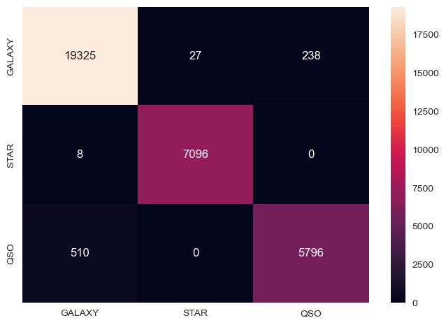

```python
test_and_conf("Bagging Classifier", BaggingClassifier(n_estimators = 20, max_samples = 1.0), xi_train, xi_test, yi_train, yi_test)
```

- 19325 are the true positives, instances that are predicted to belong to *galaxy* and actually belong to it
- 27 are the false positives, instances that are predicted to belong to *galaxy* but actually belong to *star*
- 238 are the false negatives, instances that are predicted to belong to *galaxy* but actually belong to *qso*
- 8 are the false negatives, instances that are predicted to belong to *star* but actually belong to *galaxy*
- 7096 are the true positives, instances that are predicted to belong to *star* and actually belong to it
- 0 false positives
- 510 are the false positives, instances that are predicted to belong to *qso* but actually belong to *galaxy*
- 0 false negatives
- 5796 are the true positives, instances that are predicted to belong to *qso* and acutally belong to it

#### XGBoost

```python
evaluate_model_cv(XGBClassifier(), xi_train, yi_train)
```

[output not shown]

```python
param_grid_xgb = {
    'max_depth': [10, 20]
}
grid_search(param_grid_xgb, XGBClassifier(), xi_train, yi_train)
```

[output not shown]

[output cut: 15 more lines]

```
XGBClassifier(base_score=0.5, booster='gbtree', colsample_bylevel=1,
              colsample_bynode=1, colsample_bytree=1, enable_categorical=False,
              gamma=0, gpu_id=-1, importance_type=None,
              interaction_constraints='', learning_rate=0.300000012,
              max_delta_step=0, max_depth=20, min_child_weight=1, missing=nan,
              monotone_constraints='()', n_estimators=100, n_jobs=16,
              num_parallel_tree=1, objective='multi:softprob', predictor='auto',
              random_state=0, reg_alpha=0, reg_lambda=1, scale_pos_weight=None,
              subsample=1, tree_method='exact', validate_parameters=1,
              verbosity=None)
```

```
[20:59:44] WARNING: ..\src\learner.cc:1115: Starting in XGBoost 1.3.0, the default evaluation metric used with the objective 'multi:softprob' was changed from 'merror' to 'mlogloss'. Explicitly set eval_metric if you'd like to restore the old behavior.
Accuracy Score for XGB Classifier is :  97.69696969696969 %
XGB Classifier model classification report:
              precision    recall  f1-score   support

           0       0.98      0.99      0.98     19590
           1       1.00      1.00      1.00      7104
           2       0.96      0.92      0.94      6306

    accuracy                           0.98     33000
   macro avg       0.98      0.97      0.97     33000
weighted avg       0.98      0.98      0.98     33000

XGB Classifier model confusion matrix:
```

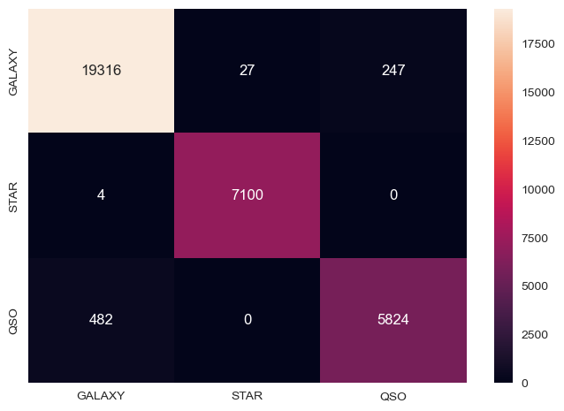

```python
test_and_conf("XGB Classifier", XGBClassifier(max_depth = 20), xi_train, xi_test, yi_train, yi_test)
```

- 19316 are the true positives, instances that are predicted to belong to *galaxy* and actually belong to it
- 27 are the false positives, instances that are predicted to belong to *galaxy* but actually belong to *star*
- 247 are the false negatives, instances that are predicted to belong to *galaxy* but actually belong to *qso*
- 4 are the false negatives, instances that are predicetd to belong to *star* but actually belong to *galaxy*
- 7100 are the true positives, instances that are predicted to belong to *star* and actually belong to it
- 0 false positives
- 482 are the false positives, instances that are predicted to belong to *qso* but actually belong to *galaxy*
- 0 false negatives
- 5824 are the true positives, instances that are predicted to belong to *qso* and acutally belong to it

#### AdaBoost

```python
evaluate_model_cv(AdaBoostClassifier(), xi_train, yi_train)
```

```
Cross-validation scores: [0.77447761 0.80492537 0.79298507 0.81059701 0.80014925 0.80223881
 0.74701493 0.80373134 0.7738806  0.77817585]
Mean score: 0.7888175847141364
Standard deviation: 0.018898639699467805
```

```python
param_grid_ada = {
    'learning_rate': [0.1, 0.5],
    'algorithm': ['SAMME', 'SAMME.R']
}
grid_search(param_grid_ada, AdaBoostClassifier(), xi_train, yi_train)
```

```
Fitting 10 folds for each of 4 candidates, totalling 40 fits
[CV 1/10] END algorithm=SAMME, learning_rate=0.1;, score=0.949 total time=   2.2s
[CV 2/10] END algorithm=SAMME, learning_rate=0.1;, score=0.949 total time=   2.2s
[CV 3/10] END algorithm=SAMME, learning_rate=0.1;, score=0.950 total time=   2.2s
[CV 4/10] END algorithm=SAMME, learning_rate=0.1;, score=0.946 total time=   2.2s
[CV 5/10] END algorithm=SAMME, learning_rate=0.1;, score=0.949 total time=   2.2s
[CV 6/10] END algorithm=SAMME, learning_rate=0.1;, score=0.947 total time=   2.2s
[CV 7/10] END algorithm=SAMME, learning_rate=0.1;, score=0.952 total time=   2.2s
[CV 8/10] END algorithm=SAMME, learning_rate=0.1;, score=0.946 total time=   2.2s
[CV 9/10] END algorithm=SAMME, learning_rate=0.1;, score=0.949 total time=   2.2s
[CV 10/10] END algorithm=SAMME, learning_rate=0.1;, score=0.940 total time=   2.2s
[CV 1/10] END algorithm=SAMME, learning_rate=0.5;, score=0.953 total time=   2.2s
[CV 2/10] END algorithm=SAMME, learning_rate=0.5;, score=0.952 total time=   2.2s
[CV 3/10] END algorithm=SAMME, learning_rate=0.5;, score=0.955 total time=   2.2s
[CV 4/10] END algorithm=SAMME, learning_rate=0.5;, score=0.950 total time=   2.2s
[CV 5/10] END algorithm=SAMME, learning_rate=0.5;, score=0.953 total time=   2.2s
[CV 6/10] END algorithm=SAMME, learning_rate=0.5;, score=0.953 total time=   2.2s
[CV 7/10] END algorithm=SAMME, learning_rate=0.5;, score=0.955 total time=   2.2s
[CV 8/10] END algorithm=SAMME, learning_rate=0.5;, score=0.949 total time=   2.2s
[CV 9/10] END algorithm=SAMME, learning_rate=0.5;, score=0.953 total time=   2.2s
[CV 10/10] END algorithm=SAMME, learning_rate=0.5;, score=0.944 total time=   2.2s
[CV 1/10] END algorithm=SAMME.R, learning_rate=0.1;, score=0.803 total time=   2.5s
[CV 2/10] END algorithm=SAMME.R, learning_rate=0.1;, score=0.801 total time=   2.5s
[CV 3/10] END algorithm=SAMME.R, learning_rate=0.1;, score=0.805 total time=   2.5s
[CV 4/10] END algorithm=SAMME.R, learning_rate=0.1;, score=0.804 total time=   2.5s
[CV 5/10] END algorithm=SAMME.R, learning_rate=0.1;, score=0.802 total time=   2.5s
[CV 6/10] END algorithm=SAMME.R, learning_rate=0.1;, score=0.801 total time=   2.5s
[CV 7/10] END algorithm=SAMME.R, learning_rate=0.1;, score=0.803 total time=   2.5s
[CV 8/10] END algorithm=SAMME.R, learning_rate=0.1;, score=0.804 total time=   2.5s
[CV 9/10] END algorithm=SAMME.R, learning_rate=0.1;, score=0.777 total time=   2.4s
[CV 10/10] END algorithm=SAMME.R, learning_rate=0.1;, score=0.774 total time=   2.5s
[CV 1/10] END algorithm=SAMME.R, learning_rate=0.5;, score=0.818 total time=   2.5s
[CV 2/10] END algorithm=SAMME.R, learning_rate=0.5;, score=0.806 total time=   2.5s
[CV 3/10] END algorithm=SAMME.R, learning_rate=0.5;, score=0.806 total time=   2.4s
[CV 4/10] END algorithm=SAMME.R, learning_rate=0.5;, score=0.807 total time=   2.5s
[CV 5/10] END algorithm=SAMME.R, learning_rate=0.5;, score=0.807 total time=   2.4s
[CV 6/10] END algorithm=SAMME.R, learning_rate=0.5;, score=0.807 total time=   2.5s
[CV 7/10] END algorithm=SAMME.R, learning_rate=0.5;, score=0.807 total time=   2.5s
[CV 8/10] END algorithm=SAMME.R, learning_rate=0.5;, score=0.814 total time=   2.5s
[CV 9/10] END algorithm=SAMME.R, learning_rate=0.5;, score=0.806 total time=   2.5s
[CV 10/10] END algorithm=SAMME.R, learning_rate=0.5;, score=0.805 total time=   2.4s
Best: 0.951760 using {'algorithm': 'SAMME', 'learning_rate': 0.5}
```

```
AdaBoostClassifier(algorithm='SAMME', learning_rate=0.5)
```

```
Accuracy Score for AdaBoost Classifier is :  95.06666666666666 %
AdaBoost Classifier model classification report:
              precision    recall  f1-score   support

           0       0.94      0.98      0.96     19590
           1       0.98      1.00      0.99      7104
           2       0.95      0.82      0.88      6306

    accuracy                           0.95     33000
   macro avg       0.96      0.93      0.94     33000
weighted avg       0.95      0.95      0.95     33000

AdaBoost Classifier model confusion matrix:
```

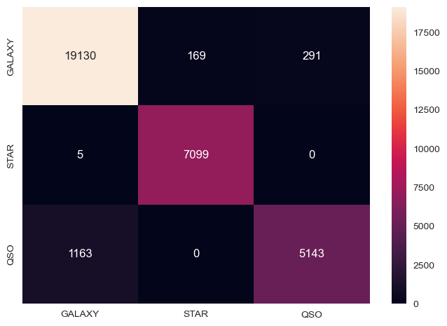

```python
test_and_conf("AdaBoost Classifier", AdaBoostClassifier(algorithm = "SAMME", learning_rate = 0.5), xi_train, xi_test, yi_train, yi_test)
```

- 19130 are the true positives, instances that are predicted to belong to *galaxy* and actually belong to it
- 169 are the false positives, instances that are predicted to belong to *galaxy* but actually belong to *star*
- 291 are the false negatives, instances that are predicted to belong to *galaxy* but actually belong to *qso*
- 5 are the false negatives, instances that are predicted to belong to *star* but actually belong to *galaxy*
- 7099 are the true positives, instances that are predicted to belong to *star* and actually belong to it
- 0 false positives
- 1163 are the false positives, instances that are predicted to belong to *qso* but actually belong to *galaxy*
- 0 false negatives
- 5143 are the true positives, instances that are predicted to belong to *qso* and acutally belong to it

#### RandomForest

```python
evaluate_model_cv(RandomForestClassifier(), xi_train, yi_train)
```

```
Cross-validation scores: [0.97895522 0.97925373 0.98       0.97835821 0.98179104 0.98044776
 0.97955224 0.97776119 0.9780597  0.97701149]
Mean score: 0.9791190598730486
Standard deviation: 0.0013379235943847992
```

```python
param_grid_rf = {
    'n_estimators': [50],
    'max_depth': [None, 20],
    'min_samples_split': [2, 5],
    'min_samples_leaf': [1, 2],
    'max_features': ['auto']
}
grid_search(param_grid_rf, RandomForestClassifier(), xi_train, yi_train)
```

```
Fitting 10 folds for each of 8 candidates, totalling 80 fits
[CV 1/10] END max_depth=None, max_features=auto, min_samples_leaf=1, min_samples_split=2, n_estimators=50;, score=0.979 total time=   4.9s
[CV 2/10] END max_depth=None, max_features=auto, min_samples_leaf=1, min_samples_split=2, n_estimators=50;, score=0.979 total time=   4.9s
[CV 3/10] END max_depth=None, max_features=auto, min_samples_leaf=1, min_samples_split=2, n_estimators=50;, score=0.980 total time=   4.8s
[CV 4/10] END max_depth=None, max_features=auto, min_samples_leaf=1, min_samples_split=2, n_estimators=50;, score=0.979 total time=   4.9s
[CV 5/10] END max_depth=None, max_features=auto, min_samples_leaf=1, min_samples_split=2, n_estimators=50;, score=0.982 total time=   4.9s
[CV 6/10] END max_depth=None, max_features=auto, min_samples_leaf=1, min_samples_split=2, n_estimators=50;, score=0.980 total time=   4.9s
[CV 7/10] END max_depth=None, max_features=auto, min_samples_leaf=1, min_samples_split=2, n_estimators=50;, score=0.979 total time=   4.9s
[CV 8/10] END max_depth=None, max_features=auto, min_samples_leaf=1, min_samples_split=2, n_estimators=50;, score=0.978 total time=   5.0s
[CV 9/10] END max_depth=None, max_features=auto, min_samples_leaf=1, min_samples_split=2, n_estimators=50;, score=0.978 total time=   4.8s
[CV 10/10] END max_depth=None, max_features=auto, min_samples_leaf=1, min_samples_split=2, n_estimators=50;, score=0.978 total time=   4.9s
[CV 1/10] END max_depth=None, max_features=auto, min_samples_leaf=1, min_samples_split=5, n_estimators=50;, score=0.979 total time=   4.9s
[CV 2/10] END max_depth=None, max_features=auto, min_samples_leaf=1, min_samples_split=5, n_estimators=50;, score=0.979 total time=   4.9s
[CV 3/10] END max_depth=None, max_features=auto, min_samples_leaf=1, min_samples_split=5, n_estimators=50;, score=0.980 total time=   4.9s
[CV 4/10] END max_depth=None, max_features=auto, min_samples_leaf=1, min_samples_split=5, n_estimators=50;, score=0.979 total time=   5.0s
[CV 5/10] END max_depth=None, max_features=auto, min_samples_leaf=1, min_samples_split=5, n_estimators=50;, score=0.981 total time=   4.9s
[CV 6/10] END max_depth=None, max_features=auto, min_samples_leaf=1, min_samples_split=5, n_estimators=50;, score=0.980 total time=   4.9s
[CV 7/10] END max_depth=None, max_features=auto, min_samples_leaf=1, min_samples_split=5, n_estimators=50;, score=0.979 total time=   4.9s
[CV 8/10] END max_depth=None, max_features=auto, min_samples_leaf=1, min_samples_split=5, n_estimators=50;, score=0.978 total time=   4.9s
[CV 9/10] END max_depth=None, max_features=auto, min_samples_leaf=1, min_samples_split=5, n_estimators=50;, score=0.977 total time=   4.9s
[CV 10/10] END max_depth=None, max_features=auto, min_samples_leaf=1, min_samples_split=5, n_estimators=50;, score=0.977 total time=   4.8s
[CV 1/10] END max_depth=None, max_features=auto, min_samples_leaf=2, min_samples_split=2, n_estimators=50;, score=0.979 total time=   4.8s
[CV 2/10] END max_depth=None, max_features=auto, min_samples_leaf=2, min_samples_split=2, n_estimators=50;, score=0.979 total time=   5.0s
[CV 3/10] END max_depth=None, max_features=auto, min_samples_leaf=2, min_samples_split=2, n_estimators=50;, score=0.980 total time=   4.9s
[CV 4/10] END max_depth=None, max_features=auto, min_samples_leaf=2, min_samples_split=2, n_estimators=50;, score=0.978 total time=   4.9s
[CV 5/10] END max_depth=None, max_features=auto, min_samples_leaf=2, min_samples_split=2, n_estimators=50;, score=0.982 total time=   4.9s
[CV 6/10] END max_depth=None, max_features=auto, min_samples_leaf=2, min_samples_split=2, n_estimators=50;, score=0.980 total time=   4.9s
[CV 7/10] END max_depth=None, max_features=auto, min_samples_leaf=2, min_samples_split=2, n_estimators=50;, score=0.979 total time=   4.9s
[CV 8/10] END max_depth=None, max_features=auto, min_samples_leaf=2, min_samples_split=2, n_estimators=50;, score=0.978 total time=   4.8s
[CV 9/10] END max_depth=None, max_features=auto, min_samples_leaf=2, min_samples_split=2, n_estimators=50;, score=0.978 total time=   4.8s
[CV 10/10] END max_depth=None, max_features=auto, min_samples_leaf=2, min_samples_split=2, n_estimators=50;, score=0.978 total time=   4.8s
[CV 1/10] END max_depth=None, max_features=auto, min_samples_leaf=2, min_samples_split=5, n_estimators=50;, score=0.979 total time=   4.8s
[CV 2/10] END max_depth=None, max_features=auto, min_samples_leaf=2, min_samples_split=5, n_estimators=50;, score=0.979 total time=   4.8s
[CV 3/10] END max_depth=None, max_features=auto, min_samples_leaf=2, min_samples_split=5, n_estimators=50;, score=0.980 total time=   4.9s
[CV 4/10] END max_depth=None, max_features=auto, min_samples_leaf=2, min_samples_split=5, n_estimators=50;, score=0.978 total time=   4.9s
[CV 5/10] END max_depth=None, max_features=auto, min_samples_leaf=2, min_samples_split=5, n_estimators=50;, score=0.982 total time=   4.9s
[CV 6/10] END max_depth=None, max_features=auto, min_samples_leaf=2, min_samples_split=5, n_estimators=50;, score=0.980 total time=   4.8s
[CV 7/10] END max_depth=None, max_features=auto, min_samples_leaf=2, min_samples_split=5, n_estimators=50;, score=0.980 total time=   4.9s
[CV 8/10] END max_depth=None, max_features=auto, min_samples_leaf=2, min_samples_split=5, n_estimators=50;, score=0.976 total time=   4.8s
[CV 9/10] END max_depth=None, max_features=auto, min_samples_leaf=2, min_samples_split=5, n_estimators=50;, score=0.978 total time=   4.9s
```

[output cut: 27 more lines]

```
[CV 7/10] END max_depth=20, max_features=auto, min_samples_leaf=2, min_samples_split=2, n_estimators=50;, score=0.980 total time=   4.9s
[CV 8/10] END max_depth=20, max_features=auto, min_samples_leaf=2, min_samples_split=2, n_estimators=50;, score=0.978 total time=   4.8s
[CV 9/10] END max_depth=20, max_features=auto, min_samples_leaf=2, min_samples_split=2, n_estimators=50;, score=0.978 total time=   4.8s
[CV 10/10] END max_depth=20, max_features=auto, min_samples_leaf=2, min_samples_split=2, n_estimators=50;, score=0.977 total time=   4.8s
[CV 1/10] END max_depth=20, max_features=auto, min_samples_leaf=2, min_samples_split=5, n_estimators=50;, score=0.979 total time=   4.8s
[CV 2/10] END max_depth=20, max_features=auto, min_samples_leaf=2, min_samples_split=5, n_estimators=50;, score=0.979 total time=   4.8s
[CV 3/10] END max_depth=20, max_features=auto, min_samples_leaf=2, min_samples_split=5, n_estimators=50;, score=0.980 total time=   4.7s
[CV 4/10] END max_depth=20, max_features=auto, min_samples_leaf=2, min_samples_split=5, n_estimators=50;, score=0.979 total time=   4.8s
[CV 5/10] END max_depth=20, max_features=auto, min_samples_leaf=2, min_samples_split=5, n_estimators=50;, score=0.981 total time=   4.8s
[CV 6/10] END max_depth=20, max_features=auto, min_samples_leaf=2, min_samples_split=5, n_estimators=50;, score=0.980 total time=   4.7s
[CV 7/10] END max_depth=20, max_features=auto, min_samples_leaf=2, min_samples_split=5, n_estimators=50;, score=0.979 total time=   4.8s
[CV 8/10] END max_depth=20, max_features=auto, min_samples_leaf=2, min_samples_split=5, n_estimators=50;, score=0.978 total time=   4.8s
[CV 9/10] END max_depth=20, max_features=auto, min_samples_leaf=2, min_samples_split=5, n_estimators=50;, score=0.977 total time=   4.8s
[CV 10/10] END max_depth=20, max_features=auto, min_samples_leaf=2, min_samples_split=5, n_estimators=50;, score=0.976 total time=   4.8s
Best: 0.979164 using {'max_depth': 20, 'max_features': 'auto', 'min_samples_leaf': 1, 'min_samples_split': 2, 'n_estimators': 50}
```

```
RandomForestClassifier(max_depth=20, n_estimators=50)
```

```
Accuracy Score for RandomForest Classifier is :  97.7151515151515 %
RandomForest Classifier model classification report:
              precision    recall  f1-score   support

           0       0.97      0.99      0.98     19590
           1       1.00      1.00      1.00      7104
           2       0.96      0.92      0.94      6306

    accuracy                           0.98     33000
   macro avg       0.98      0.97      0.97     33000
weighted avg       0.98      0.98      0.98     33000

RandomForest Classifier model confusion matrix:
```

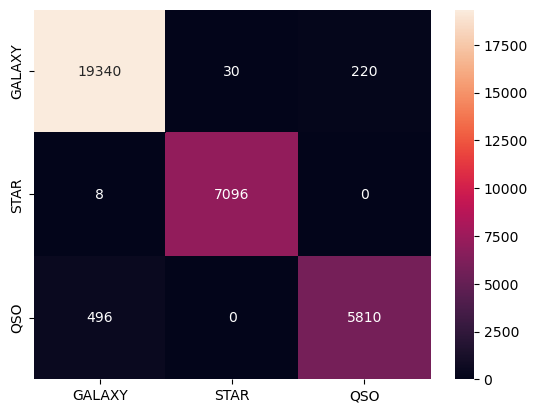

```python
test_and_conf("RandomForest Classifier", RandomForestClassifier(n_estimators = 50, max_depth = 20, min_samples_split = 2, min_samples_leaf = 1), xi_train, xi_test, yi_train, yi_test)
```

- 19340 are the true positives, instances that are predicted to belong to *galaxy* and actually belong to it
- 30 are the false positives, instances that are predicted to belong to *galaxy* but actually belong to *star*
- 220 are the false negatives, instances that are predicted to belong to *galaxy* but actually belong to *qso*
- 8 are the false negatives, instances that are predicted to belong to *star* but actually belong to *galaxy*
- 7096 are the true positives, instances that are predicted to belong to *star* and actually belong to it
- 0 false positive
- 496 are the false positives, instances that are predicted to belong to *qso* but actually belong to *galaxy*
- 0 false negatives
- 5810 are the true positives, instances that are predicted to belong to *qso* and acutally belong to it

#### ExtraTrees

```python
evaluate_model_cv(ExtraTreesClassifier(), xi_train, yi_train)
```

```
Cross-validation scores: [0.9758209  0.9761194  0.97656716 0.97447761 0.97940299 0.97537313
 0.97477612 0.97164179 0.97343284 0.97238394]
Mean score: 0.9749995878199688
Standard deviation: 0.002116809033052824
```

```python
param_grid_ex = {
    'n_estimators': [50, 200],
    'max_depth': [None]
}
grid_search(param_grid_ex, ExtraTreesClassifier(), xi_train, yi_train)
```

```
Fitting 10 folds for each of 2 candidates, totalling 20 fits
[CV 1/10] END ..max_depth=None, n_estimators=50;, score=0.974 total time=   1.3s
[CV 2/10] END ..max_depth=None, n_estimators=50;, score=0.975 total time=   1.3s
[CV 3/10] END ..max_depth=None, n_estimators=50;, score=0.977 total time=   1.2s
[CV 4/10] END ..max_depth=None, n_estimators=50;, score=0.975 total time=   1.3s
[CV 5/10] END ..max_depth=None, n_estimators=50;, score=0.979 total time=   1.3s
[CV 6/10] END ..max_depth=None, n_estimators=50;, score=0.976 total time=   1.3s
[CV 7/10] END ..max_depth=None, n_estimators=50;, score=0.974 total time=   1.3s
[CV 8/10] END ..max_depth=None, n_estimators=50;, score=0.971 total time=   1.3s
[CV 9/10] END ..max_depth=None, n_estimators=50;, score=0.973 total time=   1.3s
[CV 10/10] END .max_depth=None, n_estimators=50;, score=0.974 total time=   1.3s
[CV 1/10] END .max_depth=None, n_estimators=200;, score=0.975 total time=   5.4s
[CV 2/10] END .max_depth=None, n_estimators=200;, score=0.975 total time=   5.5s
[CV 3/10] END .max_depth=None, n_estimators=200;, score=0.976 total time=   5.4s
[CV 4/10] END .max_depth=None, n_estimators=200;, score=0.974 total time=   5.4s
[CV 5/10] END .max_depth=None, n_estimators=200;, score=0.980 total time=   5.4s
[CV 6/10] END .max_depth=None, n_estimators=200;, score=0.976 total time=   5.3s
[CV 7/10] END .max_depth=None, n_estimators=200;, score=0.975 total time=   5.4s
[CV 8/10] END .max_depth=None, n_estimators=200;, score=0.973 total time=   5.4s
[CV 9/10] END .max_depth=None, n_estimators=200;, score=0.973 total time=   5.4s
[CV 10/10] END max_depth=None, n_estimators=200;, score=0.973 total time=   5.5s
Best: 0.975029 using {'max_depth': None, 'n_estimators': 200}
```

```
ExtraTreesClassifier(n_estimators=200)
```

```
Accuracy Score for ExtraTrees Classifier is :  97.33636363636363 %
ExtraTrees Classifier model classification report:
              precision    recall  f1-score   support

           0       0.97      0.98      0.98     19590
           1       0.98      1.00      0.99      7104
           2       0.97      0.92      0.94      6306

    accuracy                           0.97     33000
   macro avg       0.97      0.97      0.97     33000
weighted avg       0.97      0.97      0.97     33000

ExtraTrees Classifier model confusion matrix:
```

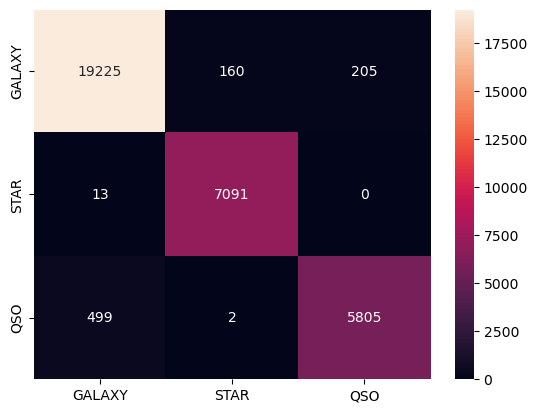

```python
test_and_conf("ExtraTrees Classifier", ExtraTreesClassifier(max_depth = None, n_estimators = 200), xi_train, xi_test, yi_train, yi_test)
```

- 19225 are the true positives, instances that are predicted to belong to *galaxy* and actually belong to it
- 160 are the false positives, instances that are predicted to belong to *galaxy* but actually belong to *star*
- 205 are the false negatives, instances that are predicted to belong to *galaxy* but actually belong to *qso*
- 13 are the false negatives, instances that are predicted to belong to *star* but actually belong to *galaxy*
- 7091 are the true positives, instances that are predicted to belong to *star* and actually belong to it
- 0 false positives
- 499 are the false positives, instances that are predicted to belong to *qso* but actually belong to *galaxy*
- 2 are the false negatives, instance that are predicted to belong to *qso* but actually belong to *star*
- 5805 are the true positives, instances that are predicted to belong to *qso* and acutally belong to it

#### DecisionTree

```python
evaluate_model_cv(DecisionTreeClassifier(), xi_train, yi_train)
```

```
Cross-validation scores: [0.96671642 0.9680597  0.96835821 0.96955224 0.96865672 0.96850746
 0.96432836 0.96447761 0.96656716 0.96372593]
Mean score: 0.9668949809840186
Standard deviation: 0.0019716972688295143
```

```python
param_grid_dt = {
    'max_depth': [None, 5],
    'min_samples_split': [2, 5]
}
grid_search(param_grid_dt, DecisionTreeClassifier(), xi_train, yi_train)
```

```
Fitting 10 folds for each of 4 candidates, totalling 40 fits
[CV 1/10] END max_depth=None, min_samples_split=2;, score=0.967 total time=   0.4s
[CV 2/10] END max_depth=None, min_samples_split=2;, score=0.968 total time=   0.4s
[CV 3/10] END max_depth=None, min_samples_split=2;, score=0.968 total time=   0.4s
[CV 4/10] END max_depth=None, min_samples_split=2;, score=0.971 total time=   0.4s
[CV 5/10] END max_depth=None, min_samples_split=2;, score=0.969 total time=   0.4s
[CV 6/10] END max_depth=None, min_samples_split=2;, score=0.968 total time=   0.4s
[CV 7/10] END max_depth=None, min_samples_split=2;, score=0.964 total time=   0.4s
[CV 8/10] END max_depth=None, min_samples_split=2;, score=0.966 total time=   0.4s
[CV 9/10] END max_depth=None, min_samples_split=2;, score=0.966 total time=   0.4s
[CV 10/10] END max_depth=None, min_samples_split=2;, score=0.963 total time=   0.4s
[CV 1/10] END max_depth=None, min_samples_split=5;, score=0.970 total time=   0.4s
[CV 2/10] END max_depth=None, min_samples_split=5;, score=0.970 total time=   0.4s
[CV 3/10] END max_depth=None, min_samples_split=5;, score=0.967 total time=   0.4s
[CV 4/10] END max_depth=None, min_samples_split=5;, score=0.971 total time=   0.4s
[CV 5/10] END max_depth=None, min_samples_split=5;, score=0.969 total time=   0.4s
[CV 6/10] END max_depth=None, min_samples_split=5;, score=0.970 total time=   0.4s
[CV 7/10] END max_depth=None, min_samples_split=5;, score=0.967 total time=   0.4s
[CV 8/10] END max_depth=None, min_samples_split=5;, score=0.966 total time=   0.4s
[CV 9/10] END max_depth=None, min_samples_split=5;, score=0.966 total time=   0.5s
[CV 10/10] END max_depth=None, min_samples_split=5;, score=0.964 total time=   0.4s
[CV 1/10] END .max_depth=5, min_samples_split=2;, score=0.964 total time=   0.1s
[CV 2/10] END .max_depth=5, min_samples_split=2;, score=0.966 total time=   0.1s
[CV 3/10] END .max_depth=5, min_samples_split=2;, score=0.966 total time=   0.1s
[CV 4/10] END .max_depth=5, min_samples_split=2;, score=0.964 total time=   0.1s
[CV 5/10] END .max_depth=5, min_samples_split=2;, score=0.966 total time=   0.1s
[CV 6/10] END .max_depth=5, min_samples_split=2;, score=0.966 total time=   0.1s
[CV 7/10] END .max_depth=5, min_samples_split=2;, score=0.968 total time=   0.1s
[CV 8/10] END .max_depth=5, min_samples_split=2;, score=0.963 total time=   0.1s
[CV 9/10] END .max_depth=5, min_samples_split=2;, score=0.964 total time=   0.1s
[CV 10/10] END max_depth=5, min_samples_split=2;, score=0.960 total time=   0.1s
[CV 1/10] END .max_depth=5, min_samples_split=5;, score=0.964 total time=   0.1s
[CV 2/10] END .max_depth=5, min_samples_split=5;, score=0.966 total time=   0.1s
[CV 3/10] END .max_depth=5, min_samples_split=5;, score=0.966 total time=   0.1s
[CV 4/10] END .max_depth=5, min_samples_split=5;, score=0.964 total time=   0.1s
[CV 5/10] END .max_depth=5, min_samples_split=5;, score=0.966 total time=   0.1s
[CV 6/10] END .max_depth=5, min_samples_split=5;, score=0.966 total time=   0.1s
[CV 7/10] END .max_depth=5, min_samples_split=5;, score=0.968 total time=   0.1s
[CV 8/10] END .max_depth=5, min_samples_split=5;, score=0.963 total time=   0.1s
[CV 9/10] END .max_depth=5, min_samples_split=5;, score=0.964 total time=   0.1s
[CV 10/10] END max_depth=5, min_samples_split=5;, score=0.960 total time=   0.1s
Best: 0.968044 using {'max_depth': None, 'min_samples_split': 5}
```

```
DecisionTreeClassifier(min_samples_split=5)
```

```
Accuracy Score for DecisionTree Classifier is :  96.6 %
DecisionTree Classifier model classification report:
              precision    recall  f1-score   support

           0       0.97      0.97      0.97     19590
           1       1.00      0.99      1.00      7104
           2       0.92      0.91      0.92      6306

    accuracy                           0.97     33000
   macro avg       0.96      0.96      0.96     33000
weighted avg       0.97      0.97      0.97     33000

DecisionTree Classifier model confusion matrix:
```

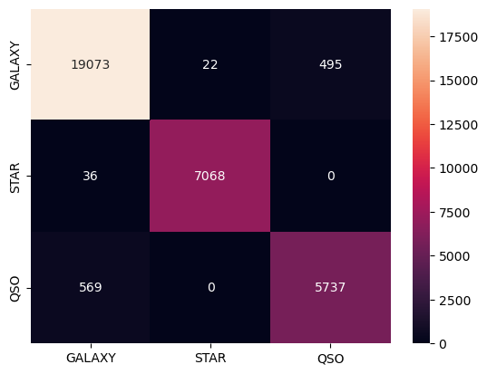

```python
test_and_conf("DecisionTree Classifier", DecisionTreeClassifier(max_depth = None, min_samples_split = 5), xi_train, xi_test, yi_train, yi_test)
```

- 19073 are the true positives, instances that are predicted to belong to *galaxy* and actually belong to it
- 22 are the false positives, instances that are predicted to belong to *galaxy* but actually belong to *star*
- 495 are the false negatives, instances that are predicted to belong to *galaxy* but actually belong to *qso*
- 36 are the false negatives, instances that are predicted to belong to *star* but actually belong to *galaxy*
- 7068 are the true positives, instances that are predicted to belong to *star* and actually belong to it
- 0 false positives
- 569 are the false positives, instances that are predicted to belong to *qso* but actually belong to *galaxy*
- 0 false negatives
- 5737 are the true positives, instances that are predicted to belong to *qso* and acutally belong to it

#### GaussianNB

```python
evaluate_model_cv(GaussianNB(), xi_train, yi_train)
```

```
Cross-validation scores: [0.92552239 0.92       0.92507463 0.9238806  0.92223881 0.92059701
 0.92477612 0.91343284 0.91716418 0.91983878]
Mean score: 0.9212525349071926
Standard deviation: 0.0036741627112492716
```

```python
param_grid_gaus = {
    'var_smoothing': [1e-9, 1e-8, 1e-7, 1e-6, 1e-5, 1e-4, 1e-3, 1e-2]
}
grid_search(param_grid_gaus, GaussianNB(), xi_train, yi_train)
```

```
Fitting 10 folds for each of 8 candidates, totalling 80 fits
[CV 1/10] END ..............var_smoothing=1e-09;, score=0.926 total time=   0.0s
[CV 2/10] END ..............var_smoothing=1e-09;, score=0.920 total time=   0.0s
[CV 3/10] END ..............var_smoothing=1e-09;, score=0.925 total time=   0.0s
[CV 4/10] END ..............var_smoothing=1e-09;, score=0.924 total time=   0.0s
[CV 5/10] END ..............var_smoothing=1e-09;, score=0.922 total time=   0.0s
[CV 6/10] END ..............var_smoothing=1e-09;, score=0.921 total time=   0.0s
[CV 7/10] END ..............var_smoothing=1e-09;, score=0.925 total time=   0.0s
[CV 8/10] END ..............var_smoothing=1e-09;, score=0.913 total time=   0.0s
[CV 9/10] END ..............var_smoothing=1e-09;, score=0.917 total time=   0.0s
[CV 10/10] END .............var_smoothing=1e-09;, score=0.920 total time=   0.0s
[CV 1/10] END ..............var_smoothing=1e-08;, score=0.926 total time=   0.0s
[CV 2/10] END ..............var_smoothing=1e-08;, score=0.920 total time=   0.0s
[CV 3/10] END ..............var_smoothing=1e-08;, score=0.925 total time=   0.0s
[CV 4/10] END ..............var_smoothing=1e-08;, score=0.924 total time=   0.0s
[CV 5/10] END ..............var_smoothing=1e-08;, score=0.922 total time=   0.0s
[CV 6/10] END ..............var_smoothing=1e-08;, score=0.921 total time=   0.0s
[CV 7/10] END ..............var_smoothing=1e-08;, score=0.925 total time=   0.0s
[CV 8/10] END ..............var_smoothing=1e-08;, score=0.913 total time=   0.0s
[CV 9/10] END ..............var_smoothing=1e-08;, score=0.917 total time=   0.0s
[CV 10/10] END .............var_smoothing=1e-08;, score=0.920 total time=   0.0s
[CV 1/10] END ..............var_smoothing=1e-07;, score=0.926 total time=   0.0s
[CV 2/10] END ..............var_smoothing=1e-07;, score=0.920 total time=   0.0s
[CV 3/10] END ..............var_smoothing=1e-07;, score=0.925 total time=   0.0s
[CV 4/10] END ..............var_smoothing=1e-07;, score=0.924 total time=   0.0s
[CV 5/10] END ..............var_smoothing=1e-07;, score=0.922 total time=   0.0s
[CV 6/10] END ..............var_smoothing=1e-07;, score=0.921 total time=   0.0s
[CV 7/10] END ..............var_smoothing=1e-07;, score=0.925 total time=   0.0s
[CV 8/10] END ..............var_smoothing=1e-07;, score=0.914 total time=   0.0s
[CV 9/10] END ..............var_smoothing=1e-07;, score=0.917 total time=   0.0s
[CV 10/10] END .............var_smoothing=1e-07;, score=0.920 total time=   0.0s
[CV 1/10] END ..............var_smoothing=1e-06;, score=0.926 total time=   0.0s
[CV 2/10] END ..............var_smoothing=1e-06;, score=0.921 total time=   0.0s
[CV 3/10] END ..............var_smoothing=1e-06;, score=0.926 total time=   0.0s
[CV 4/10] END ..............var_smoothing=1e-06;, score=0.925 total time=   0.0s
[CV 5/10] END ..............var_smoothing=1e-06;, score=0.923 total time=   0.0s
[CV 6/10] END ..............var_smoothing=1e-06;, score=0.922 total time=   0.0s
[CV 7/10] END ..............var_smoothing=1e-06;, score=0.926 total time=   0.0s
[CV 8/10] END ..............var_smoothing=1e-06;, score=0.915 total time=   0.0s
[CV 9/10] END ..............var_smoothing=1e-06;, score=0.918 total time=   0.0s
```

[output cut: 27 more lines]

```
[CV 7/10] END ..............var_smoothing=0.001;, score=0.884 total time=   0.0s
[CV 8/10] END ..............var_smoothing=0.001;, score=0.872 total time=   0.0s
[CV 9/10] END ..............var_smoothing=0.001;, score=0.875 total time=   0.0s
[CV 10/10] END .............var_smoothing=0.001;, score=0.876 total time=   0.0s
[CV 1/10] END ...............var_smoothing=0.01;, score=0.753 total time=   0.0s
[CV 2/10] END ...............var_smoothing=0.01;, score=0.743 total time=   0.0s
[CV 3/10] END ...............var_smoothing=0.01;, score=0.746 total time=   0.0s
[CV 4/10] END ...............var_smoothing=0.01;, score=0.745 total time=   0.0s
[CV 5/10] END ...............var_smoothing=0.01;, score=0.747 total time=   0.0s
[CV 6/10] END ...............var_smoothing=0.01;, score=0.744 total time=   0.0s
[CV 7/10] END ...............var_smoothing=0.01;, score=0.758 total time=   0.0s
[CV 8/10] END ...............var_smoothing=0.01;, score=0.749 total time=   0.0s
[CV 9/10] END ...............var_smoothing=0.01;, score=0.745 total time=   0.0s
[CV 10/10] END ..............var_smoothing=0.01;, score=0.740 total time=   0.0s
Best: 0.922432 using {'var_smoothing': 1e-05}
```

```
GaussianNB(var_smoothing=1e-05)
```

```
Accuracy Score for GaussianNB is :  92.4939393939394 %
GaussianNB model classification report:
              precision    recall  f1-score   support

           0       0.96      0.91      0.94     19590
           1       0.97      1.00      0.99      7104
           2       0.78      0.88      0.83      6306

    accuracy                           0.92     33000
   macro avg       0.91      0.93      0.92     33000
weighted avg       0.93      0.92      0.93     33000

GaussianNB model confusion matrix:
```

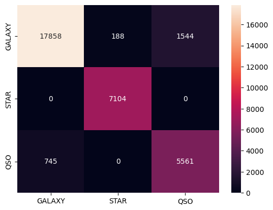

```python
test_and_conf("GaussianNB", GaussianNB(var_smoothing = 1e-05), xi_train, xi_test, yi_train, yi_test)
```

- 17858 are the true positives, instances that are predicted to belong to *galaxy* and actually belong to it
- 188 are the false positives, instances that are predicted to belong to *galaxy* but actually belong to *star*
- 1544 are the false negatives, instances that are predicted to belong to *galaxy* but actually belong to *qso*
- 0 false negatives
- 7104 are the true positives, instances that are predicted to belong to *star* and actually belong to it
- 0 false positives
- 745 are the false positives, instances that are predicted to belong to *qso* but actually belong to *galaxy*
- 0 false negatives
- 5561 are the true positives, instances that are predicted to belong to *qso* and acutally belong to it

## 5. Unsupervised Learning Techniques

*Unsupervised learning* techniques, such as clustering and dimensionality reduction, are used to discover patterns and relationships in the data without the use of labeled examples. Our work is to remove the *class* object from the dataset and then assign the remanining features to a variable that will be used as data for the principal component analysis.

Libraries used in this topic:

```python
from sklearn.cluster import KMeans
from sklearn.decomposition import PCA
from sklearn.metrics import silhouette_score
from sklearn.pipeline import Pipeline
```

Preparing the data for the process.

```python
Features = data.drop(["class"], axis = 1).columns
X = data[Features]
```

### 5.1 Principal Component Analysis

*PCA* is often used as a preprocessing step before applying machine learning algorithms, especially usupervised learning models, to the data, as it can help to reduce the complexity of the data and improve the performance of the algorithms. It can also be used for data visualization, as it can help to reduce the dimensions of high-dimensional data to a lower number of dimensions that can be visualized on a 2D or 3D plot.

In the following box it is possible to see the application of *PCA*.

```python
scaler = StandardScaler()
X_scaled = scaler.fit_transform(X)
X_pca = PCA(n_components = 2).fit_transform(X_scaled)
X_pca.shape
```

```
(99999, 2)
```

After the scaling of the data the code applies *PCA* to the scaled data, with the number of components set to 2. This will transform the data into a new set of 2 dimensions, which are the principal components that capture the most variance in the data.

### 5.2 K-means

*K-means* is used to group data points into clusters based on their similarity. It works by iteratively assigning each data point to the cluster with the nearest mean, and then updating the cluster means to the mean of the data points assigned to that cluster. The process is repeated until the cluster assignments no longer change, or some other stopping criterion is met.

In this case, a list is used to save the silhoutte score and the number of clusters is set to the variable *i* that ranges from 2 to 10.

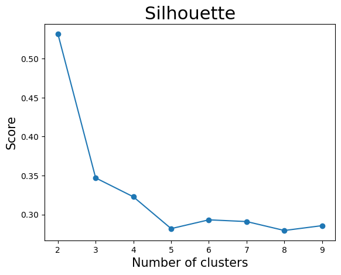

```python
sc = []
for i in range(2, 10):
    kmeans = Pipeline([("scaling", StandardScaler()), ("clustering", KMeans(n_clusters = i, init = 'k-means++', max_iter = 20, n_init = 10, random_state = 0))]).fit(X)
    score = silhouette_score(X, kmeans["clustering"].labels_)
    sc.append(score)
plt.plot(range(2, 10), sc, marker = "o")
plt.title('Silhouette', fontsize = 22)
plt.xlabel('Number of clusters', fontsize = 15)
plt.ylabel('Score', fontsize = 15)
plt.show()
```

In our case, we have 3 classes: stars, galaxies and quasars. One possible reason why the silhouette score is highest for 2 clusters is that the data may not be well-suited for k-means clustering. K-means assumes that the data consists of a fixed number of spherical clusters, and it may not be able to accurately identify more complex patterns in the data.

It's also possible that the data is simply not well-separated into distinct clusters, and no matter how many clusters you use, the silhouette score will not be very high. In this case, k-means may not be the best clustering method our data.

In the following box there is the print of all the possible clusters with k that ranges from 2 to 10, according to the previous value of *i*. As it can be observed the printing phase goes until 9 clusters, and it is based on the first component and the second component of the *PCA*.

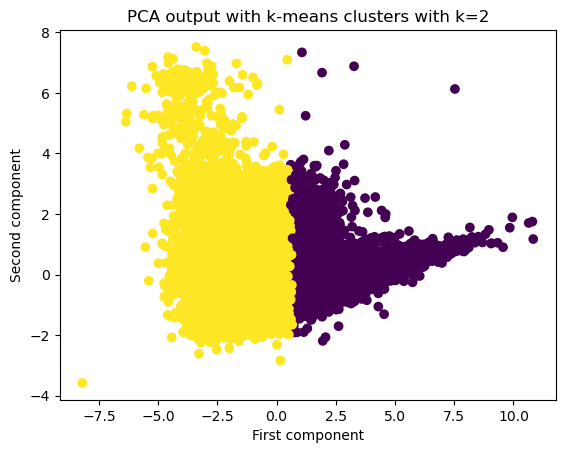

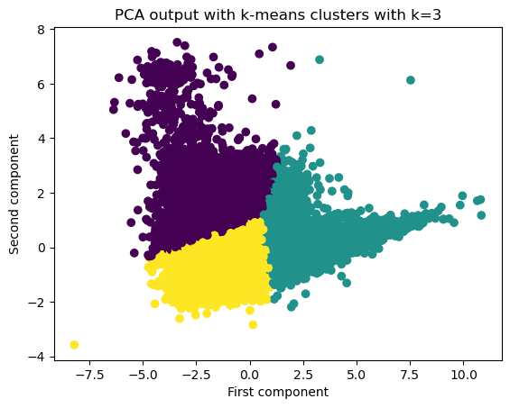

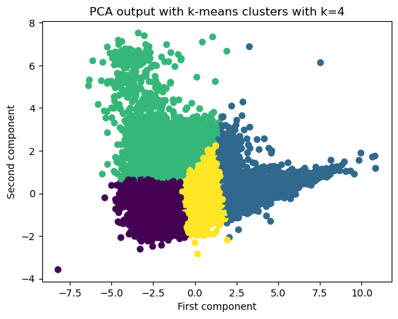

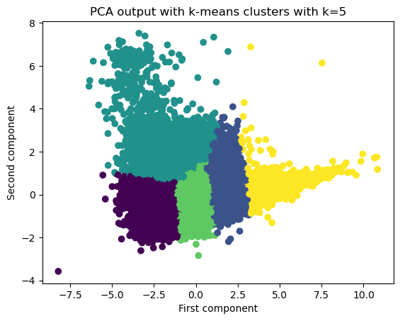

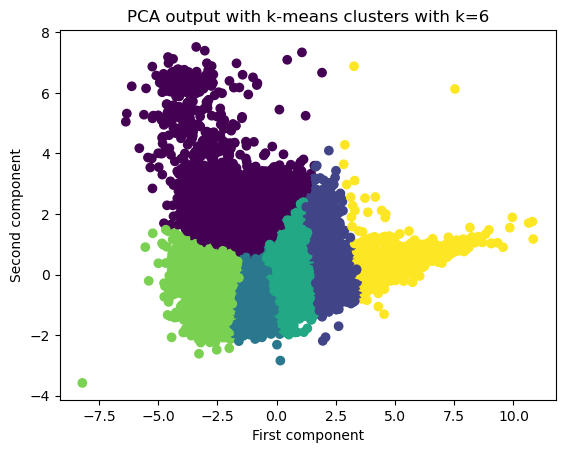

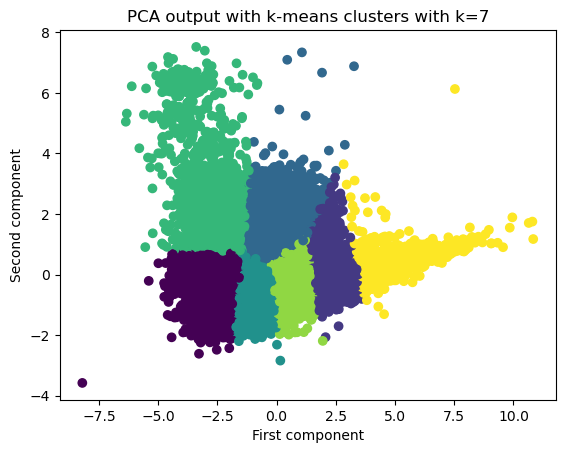

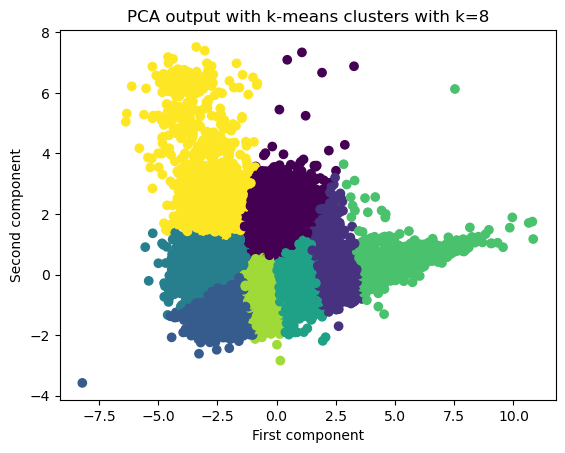

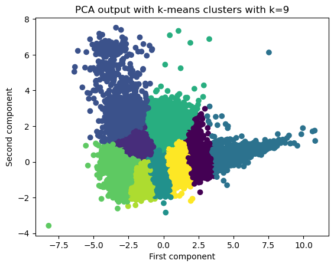

```python
for k in range (2,10):
 kmeans = KMeans(n_clusters=k)
 clusters = kmeans.fit_predict(X_pca)
 # Create a scatterplot of the PCA output
 plt.scatter(X_pca[:, 0], X_pca[:, 1], c=clusters, cmap='viridis')
 plt.xlabel('First component')
 plt.ylabel('Second component')
 plt.title('PCA output with k-means clusters with k={}'.format(k))
 plt.show()
```

Unfortunately is not possible to try other clustering methods due to computational power.